# Supplementary research evidence

| subset | leg | model | metric | block | delta | lo | hi |
| --- | --- | --- | --- | --- | --- | --- | --- |
| all | long | rates | MAE | 26 | 0.00726024 | -6.79456e-05 | 0.0161932 |
| all | long | rates | MAE | 52 | 0.00726024 | -0.0016943 | 0.0185948 |
| all | long | rates | MSE | 26 | 0.0227185 | -0.00241341 | 0.0551382 |
| all | long | rates | MSE | 52 | 0.0227185 | -0.00626913 | 0.0615503 |
| all | long | credit | MAE | 26 | 0.00639189 | -0.00221709 | 0.0168337 |
| all | long | credit | MAE | 52 | 0.00639189 | -0.00213598 | 0.0155498 |
| all | long | credit | MSE | 26 | 0.0293068 | -0.00200873 | 0.0746493 |
| all | long | credit | MSE | 52 | 0.0293068 | -0.000979736 | 0.0701089 |
| all | long | both | MAE | 26 | 0.0129442 | 0.00273872 | 0.0257044 |
| all | long | both | MAE | 52 | 0.0129442 | 0.000621844 | 0.0287066 |
| all | long | both | MSE | 26 | 0.0513257 | 0.0147814 | 0.0975304 |
| all | long | both | MSE | 52 | 0.0513257 | 0.0124102 | 0.102954 |
| all | short | rates | MAE | 26 | 0.00834 | -0.0279106 | 0.0470791 |
| all | short | rates | MAE | 52 | 0.00834 | -0.0360215 | 0.0592097 |
| all | short | rates | MSE | 26 | 0.0258335 | -0.200947 | 0.26935 |
| all | short | rates | MSE | 52 | 0.0258335 | -0.265244 | 0.363663 |
| all | short | credit | MAE | 26 | 0.00265876 | -0.020647 | 0.0264562 |
| all | short | credit | MAE | 52 | 0.00265876 | -0.0245269 | 0.0286546 |
| all | short | credit | MSE | 26 | -0.0204896 | -0.167379 | 0.121292 |
| all | short | credit | MSE | 52 | -0.0204896 | -0.198743 | 0.135698 |
| all | short | both | MAE | 26 | 0.0192982 | -0.022238 | 0.0653675 |
| all | short | both | MAE | 52 | 0.0192982 | -0.0338176 | 0.0815111 |
| all | short | both | MSE | 26 | 0.0833279 | -0.194522 | 0.421974 |
| all | short | both | MSE | 52 | 0.0833279 | -0.276178 | 0.526403 |
| all | net | rates | MAE | 26 | 0.0205191 | -0.0256861 | 0.0735818 |
| all | net | rates | MAE | 52 | 0.0205191 | -0.0385565 | 0.0961915 |
| all | net | rates | MSE | 26 | 0.137405 | -0.243788 | 0.617756 |
| all | net | rates | MSE | 52 | 0.137405 | -0.371073 | 0.757718 |
| all | net | credit | MAE | 26 | -0.000992956 | -0.0244243 | 0.0267676 |
| all | net | credit | MAE | 52 | -0.000992956 | -0.0259351 | 0.0258893 |

[output cut: 186 more lines]

**macro scenario pairs 520 7: 216 result rows**

| subset | leg | model | metric | block | delta | lo | hi |
| --- | --- | --- | --- | --- | --- | --- | --- |
| all | long | rates | MAE | 26 | 0.00630408 | 0.00145646 | 0.0125721 |
| all | long | rates | MAE | 52 | 0.00630408 | 0.000360746 | 0.0143166 |
| all | long | rates | MSE | 26 | 0.0200791 | 0.00372369 | 0.042723 |
| all | long | rates | MSE | 52 | 0.0200791 | 0.00149538 | 0.0459683 |
| all | long | credit | MAE | 26 | 0.00309914 | -0.0021799 | 0.0104295 |
| all | long | credit | MAE | 52 | 0.00309914 | -0.00235424 | 0.00961173 |
| all | long | credit | MSE | 26 | 0.0137493 | -0.00694257 | 0.0425678 |
| all | long | credit | MSE | 52 | 0.0137493 | -0.00574447 | 0.0398283 |
| all | long | both | MAE | 26 | 0.00790454 | 0.000838822 | 0.0170869 |
| all | long | both | MAE | 52 | 0.00790454 | -0.000448285 | 0.0184166 |
| all | long | both | MSE | 26 | 0.0323121 | 0.0061293 | 0.0700313 |
| all | long | both | MSE | 52 | 0.0323121 | 0.00474718 | 0.0682477 |
| all | short | rates | MAE | 26 | -0.00232019 | -0.0283863 | 0.0227502 |
| all | short | rates | MAE | 52 | -0.00232019 | -0.0342218 | 0.0297158 |
| all | short | rates | MSE | 26 | 0.00253434 | -0.1494 | 0.151427 |
| all | short | rates | MSE | 52 | 0.00253434 | -0.188422 | 0.192018 |
| all | short | credit | MAE | 26 | -0.00584423 | -0.0280163 | 0.0163598 |
| all | short | credit | MAE | 52 | -0.00584423 | -0.0322185 | 0.02017 |
| all | short | credit | MSE | 26 | 0.00221506 | -0.169621 | 0.178149 |
| all | short | credit | MSE | 52 | 0.00221506 | -0.195141 | 0.210715 |
| all | short | both | MAE | 26 | -0.00332229 | -0.0327817 | 0.0286567 |
| all | short | both | MAE | 52 | -0.00332229 | -0.0413317 | 0.0355397 |
| all | short | both | MSE | 26 | 0.0221422 | -0.172846 | 0.229525 |
| all | short | both | MSE | 52 | 0.0221422 | -0.232022 | 0.282735 |
| all | net | rates | MAE | 26 | 0.0117394 | -0.0225681 | 0.0477988 |
| all | net | rates | MAE | 52 | 0.0117394 | -0.0293253 | 0.0598172 |
| all | net | rates | MSE | 26 | 0.0980836 | -0.14694 | 0.382918 |
| all | net | rates | MSE | 52 | 0.0980836 | -0.217703 | 0.450109 |
| all | net | credit | MAE | 26 | -0.0115331 | -0.0332435 | 0.0117881 |
| all | net | credit | MAE | 52 | -0.0115331 | -0.0359296 | 0.0126413 |

[output cut: 186 more lines]

**macro scenario scores 156 7: 72 result rows**

| subset | leg | model | n | MAE | RMSE |
| --- | --- | --- | --- | --- | --- |
| all | long | market | 1200 | 0.886608 | 1.24038 |
| all | long | rates | 1200 | 0.89961 | 1.25556 |
| all | long | credit | 1200 | 0.899837 | 1.26166 |
| all | long | both | 1200 | 0.91411 | 1.27749 |
| all | short | market | 1200 | 1.28819 | 1.93275 |
| all | short | rates | 1200 | 1.30486 | 1.96044 |
| all | short | credit | 1200 | 1.29085 | 1.92458 |
| all | short | both | 1200 | 1.32582 | 1.99448 |
| all | net | market | 1200 | 1.86568 | 2.7064 |
| all | net | rates | 1200 | 1.89382 | 2.75903 |
| all | net | credit | 1200 | 1.86953 | 2.71923 |
| all | net | both | 1200 | 1.9163 | 2.80476 |
| bear | long | market | 238 | 1.20834 | 1.58815 |
| bear | long | rates | 238 | 1.21361 | 1.58646 |
| bear | long | credit | 238 | 1.24071 | 1.62455 |
| bear | long | both | 238 | 1.24263 | 1.61985 |
| bear | short | market | 238 | 1.92083 | 2.66623 |
| bear | short | rates | 238 | 1.89219 | 2.63287 |
| bear | short | credit | 238 | 1.94564 | 2.66284 |
| bear | short | both | 238 | 1.93425 | 2.64903 |
| bear | net | market | 238 | 2.90296 | 3.84344 |
| bear | net | rates | 238 | 2.84023 | 3.79756 |
| bear | net | credit | 238 | 2.95689 | 3.89739 |
| bear | net | both | 238 | 2.91916 | 3.85798 |
| bear_rebound | long | market | 59 | 1.6159 | 2.04386 |
| bear_rebound | long | rates | 59 | 1.61102 | 2.03593 |
| bear_rebound | long | credit | 59 | 1.62851 | 2.0459 |
| bear_rebound | long | both | 59 | 1.63466 | 2.04824 |
| bear_rebound | short | market | 59 | 2.48696 | 3.37672 |
| bear_rebound | short | rates | 59 | 2.42181 | 3.32961 |
| bear_rebound | short | credit | 59 | 2.46906 | 3.31386 |
| bear_rebound | short | both | 59 | 2.48357 | 3.34433 |
| bear_rebound | net | market | 59 | 3.95016 | 5.04283 |
| bear_rebound | net | rates | 59 | 3.8178 | 4.95374 |
| bear_rebound | net | credit | 59 | 3.95847 | 4.99338 |
| bear_rebound | net | both | 59 | 3.91129 | 4.96906 |
| 2000_2016 | long | market | 887 | 0.89726 | 1.263 |
| 2000_2016 | long | rates | 887 | 0.905349 | 1.26718 |
| 2000_2016 | long | credit | 887 | 0.905523 | 1.27116 |
| 2000_2016 | long | both | 887 | 0.914828 | 1.27853 |
| 2000_2016 | short | market | 887 | 1.23911 | 1.84551 |
| 2000_2016 | short | rates | 887 | 1.2356 | 1.83248 |
| 2000_2016 | short | credit | 887 | 1.24554 | 1.83946 |
| 2000_2016 | short | both | 887 | 1.2499 | 1.84173 |
| 2000_2016 | net | market | 887 | 1.884 | 2.73981 |
| 2000_2016 | net | rates | 887 | 1.87139 | 2.73031 |
| 2000_2016 | net | credit | 887 | 1.88804 | 2.74242 |
| 2000_2016 | net | both | 887 | 1.88763 | 2.74799 |
| 2017_2022 | long | market | 313 | 0.856423 | 1.17394 |
| 2017_2022 | long | rates | 313 | 0.883347 | 1.22204 |
| 2017_2022 | long | credit | 313 | 0.883724 | 1.23435 |
| 2017_2022 | long | both | 313 | 0.912077 | 1.27455 |
| 2017_2022 | short | market | 313 | 1.42727 | 2.16093 |
| 2017_2022 | short | rates | 313 | 1.50114 | 2.28446 |
| 2017_2022 | short | credit | 313 | 1.41925 | 2.14755 |
| 2017_2022 | short | both | 313 | 1.54099 | 2.37456 |
| 2017_2022 | net | market | 313 | 1.81377 | 2.60941 |
| 2017_2022 | net | rates | 313 | 1.95739 | 2.83884 |
| 2017_2022 | net | credit | 313 | 1.81708 | 2.65239 |
| 2017_2022 | net | both | 313 | 1.99754 | 2.95973 |
| exclude_crises | long | market | 1042 | 0.852919 | 1.18335 |
| exclude_crises | long | rates | 1042 | 0.869604 | 1.20507 |
| exclude_crises | long | credit | 1042 | 0.860277 | 1.19254 |
| exclude_crises | long | both | 1042 | 0.880287 | 1.21989 |
| exclude_crises | short | market | 1042 | 1.08455 | 1.53164 |
| exclude_crises | short | rates | 1042 | 1.10636 | 1.584 |
| exclude_crises | short | credit | 1042 | 1.08273 | 1.52253 |
| exclude_crises | short | both | 1042 | 1.12327 | 1.62283 |
| exclude_crises | net | market | 1042 | 1.63032 | 2.29207 |
| exclude_crises | net | rates | 1042 | 1.67149 | 2.38034 |
| exclude_crises | net | credit | 1042 | 1.6262 | 2.29688 |
| exclude_crises | net | both | 1042 | 1.68984 | 2.43375 |

**macro scenario scores 260 14: 72 result rows**

| subset | leg | model | n | MAE | RMSE |
| --- | --- | --- | --- | --- | --- |
| all | long | market | 1200 | 0.859716 | 1.19369 |
| all | long | rates | 1200 | 0.867376 | 1.20408 |
| all | long | credit | 1200 | 0.86607 | 1.20575 |
| all | long | both | 1200 | 0.872899 | 1.21549 |
| all | short | market | 1200 | 1.27429 | 1.90829 |
| all | short | rates | 1200 | 1.28269 | 1.91566 |
| all | short | credit | 1200 | 1.27679 | 1.90344 |
| all | short | both | 1200 | 1.29366 | 1.93065 |
| all | net | market | 1200 | 1.82591 | 2.63826 |
| all | net | rates | 1200 | 1.84741 | 2.66606 |
| all | net | credit | 1200 | 1.82525 | 2.65101 |
| all | net | both | 1200 | 1.85413 | 2.68933 |
| bear | long | market | 238 | 1.15593 | 1.48376 |
| bear | long | rates | 238 | 1.1615 | 1.49101 |
| bear | long | credit | 238 | 1.1818 | 1.51062 |
| bear | long | both | 238 | 1.17602 | 1.51096 |
| bear | short | market | 238 | 1.90295 | 2.64602 |
| bear | short | rates | 238 | 1.84662 | 2.59154 |
| bear | short | credit | 238 | 1.88929 | 2.62673 |
| bear | short | both | 238 | 1.86615 | 2.59128 |
| bear | net | market | 238 | 2.8166 | 3.72582 |
| bear | net | rates | 238 | 2.75492 | 3.67113 |
| bear | net | credit | 238 | 2.83794 | 3.75656 |
| bear | net | both | 238 | 2.80538 | 3.70776 |
| bear_rebound | long | market | 59 | 1.51632 | 1.89812 |
| bear_rebound | long | rates | 59 | 1.51213 | 1.90318 |
| bear_rebound | long | credit | 59 | 1.52975 | 1.91131 |
| bear_rebound | long | both | 59 | 1.51265 | 1.89891 |
| bear_rebound | short | market | 59 | 2.45361 | 3.31123 |
| bear_rebound | short | rates | 59 | 2.32609 | 3.2254 |
| bear_rebound | short | credit | 59 | 2.37569 | 3.23136 |
| bear_rebound | short | both | 59 | 2.34438 | 3.22491 |
| bear_rebound | net | market | 59 | 3.79511 | 4.86435 |
| bear_rebound | net | rates | 59 | 3.67506 | 4.7648 |
| bear_rebound | net | credit | 59 | 3.7702 | 4.81096 |
| bear_rebound | net | both | 59 | 3.73531 | 4.76461 |
| 2000_2016 | long | market | 887 | 0.86409 | 1.20436 |
| 2000_2016 | long | rates | 887 | 0.86965 | 1.20967 |
| 2000_2016 | long | credit | 887 | 0.866923 | 1.2079 |
| 2000_2016 | long | both | 887 | 0.872123 | 1.21529 |
| 2000_2016 | short | market | 887 | 1.23164 | 1.82823 |
| 2000_2016 | short | rates | 887 | 1.23394 | 1.81795 |
| 2000_2016 | short | credit | 887 | 1.23428 | 1.81669 |
| 2000_2016 | short | both | 887 | 1.24007 | 1.8208 |
| 2000_2016 | net | market | 887 | 1.84108 | 2.65417 |
| 2000_2016 | net | rates | 887 | 1.84087 | 2.6538 |
| 2000_2016 | net | credit | 887 | 1.83589 | 2.65093 |
| 2000_2016 | net | both | 887 | 1.84525 | 2.66202 |
| 2017_2022 | long | market | 313 | 0.847321 | 1.16292 |
| 2017_2022 | long | rates | 313 | 0.860932 | 1.18811 |
| 2017_2022 | long | credit | 313 | 0.86365 | 1.19961 |
| 2017_2022 | long | both | 313 | 0.875097 | 1.21607 |
| 2017_2022 | short | market | 313 | 1.39516 | 2.1188 |
| 2017_2022 | short | rates | 313 | 1.42084 | 2.16878 |
| 2017_2022 | short | credit | 313 | 1.39725 | 2.13016 |
| 2017_2022 | short | both | 313 | 1.44554 | 2.21253 |
| 2017_2022 | net | market | 313 | 1.78291 | 2.59262 |
| 2017_2022 | net | rates | 313 | 1.86594 | 2.7005 |
| 2017_2022 | net | credit | 313 | 1.79512 | 2.65121 |
| 2017_2022 | net | both | 313 | 1.87927 | 2.76524 |
| exclude_crises | long | market | 1042 | 0.832107 | 1.15559 |
| exclude_crises | long | rates | 1042 | 0.842847 | 1.16952 |
| exclude_crises | long | credit | 1042 | 0.834818 | 1.16003 |
| exclude_crises | long | both | 1042 | 0.845299 | 1.17437 |
| exclude_crises | short | market | 1042 | 1.07224 | 1.51351 |
| exclude_crises | short | rates | 1042 | 1.08772 | 1.54177 |
| exclude_crises | short | credit | 1042 | 1.07183 | 1.50465 |
| exclude_crises | short | both | 1042 | 1.0965 | 1.56075 |
| exclude_crises | net | market | 1042 | 1.60023 | 2.24137 |
| exclude_crises | net | rates | 1042 | 1.63266 | 2.29871 |
| exclude_crises | net | credit | 1042 | 1.5915 | 2.24479 |
| exclude_crises | net | both | 1042 | 1.63555 | 2.32489 |

**macro scenario scores 260 7: 72 result rows**

| subset | leg | model | n | MAE | RMSE |
| --- | --- | --- | --- | --- | --- |
| all | long | market | 1200 | 0.860543 | 1.19583 |
| all | long | rates | 1200 | 0.867803 | 1.20529 |
| all | long | credit | 1200 | 0.866935 | 1.20802 |
| all | long | both | 1200 | 0.873487 | 1.2171 |
| all | short | market | 1200 | 1.27292 | 1.90642 |
| all | short | rates | 1200 | 1.28126 | 1.91318 |
| all | short | credit | 1200 | 1.27558 | 1.90103 |
| all | short | both | 1200 | 1.29222 | 1.92815 |
| all | net | market | 1200 | 1.82488 | 2.638 |
| all | net | rates | 1200 | 1.8454 | 2.66391 |
| all | net | credit | 1200 | 1.82389 | 2.64976 |
| all | net | both | 1200 | 1.85224 | 2.68692 |
| bear | long | market | 238 | 1.15808 | 1.49022 |
| bear | long | rates | 238 | 1.16268 | 1.49504 |
| bear | long | credit | 238 | 1.1835 | 1.51724 |
| bear | long | both | 238 | 1.17682 | 1.51568 |
| bear | short | market | 238 | 1.90063 | 2.64246 |
| bear | short | rates | 238 | 1.84358 | 2.58698 |
| bear | short | credit | 238 | 1.88613 | 2.62088 |
| bear | short | both | 238 | 1.86217 | 2.58459 |
| bear | net | market | 238 | 2.81637 | 3.72763 |
| bear | net | rates | 238 | 2.75315 | 3.67008 |
| bear | net | credit | 238 | 2.83647 | 3.75567 |
| bear | net | both | 238 | 2.80303 | 3.70463 |
| bear_rebound | long | market | 59 | 1.51825 | 1.90533 |
| bear_rebound | long | rates | 59 | 1.51305 | 1.90785 |
| bear_rebound | long | credit | 59 | 1.52836 | 1.9138 |
| bear_rebound | long | both | 59 | 1.51149 | 1.90107 |
| bear_rebound | short | market | 59 | 2.45139 | 3.30714 |
| bear_rebound | short | rates | 59 | 2.32339 | 3.22138 |
| bear_rebound | short | credit | 59 | 2.37312 | 3.22687 |
| bear_rebound | short | both | 59 | 2.34032 | 3.22116 |
| bear_rebound | net | market | 59 | 3.79344 | 4.86757 |
| bear_rebound | net | rates | 59 | 3.67194 | 4.76461 |
| bear_rebound | net | credit | 59 | 3.7656 | 4.80915 |
| bear_rebound | net | both | 59 | 3.73152 | 4.76212 |
| 2000_2016 | long | market | 887 | 0.865071 | 1.20709 |
| 2000_2016 | long | rates | 887 | 0.870381 | 1.21151 |
| 2000_2016 | long | credit | 887 | 0.868031 | 1.21093 |
| 2000_2016 | long | both | 887 | 0.873056 | 1.2177 |
| 2000_2016 | short | market | 887 | 1.2299 | 1.82577 |
| 2000_2016 | short | rates | 887 | 1.23231 | 1.81515 |
| 2000_2016 | short | credit | 887 | 1.23266 | 1.81327 |
| 2000_2016 | short | both | 887 | 1.23841 | 1.8175 |
| 2000_2016 | net | market | 887 | 1.8401 | 2.65404 |
| 2000_2016 | net | rates | 887 | 1.83926 | 2.65214 |
| 2000_2016 | net | credit | 887 | 1.83475 | 2.64949 |
| 2000_2016 | net | both | 887 | 1.84403 | 2.6599 |
| 2017_2022 | long | market | 313 | 0.84771 | 1.16332 |
| 2017_2022 | long | rates | 313 | 0.860499 | 1.1875 |
| 2017_2022 | long | credit | 313 | 0.863829 | 1.19974 |
| 2017_2022 | long | both | 313 | 0.874709 | 1.21542 |
| 2017_2022 | short | market | 313 | 1.39484 | 2.11834 |
| 2017_2022 | short | rates | 313 | 1.41997 | 2.16703 |
| 2017_2022 | short | credit | 313 | 1.3972 | 2.13018 |
| 2017_2022 | short | both | 313 | 1.44471 | 2.21184 |
| 2017_2022 | net | market | 313 | 1.78174 | 2.59198 |
| 2017_2022 | net | rates | 313 | 1.8628 | 2.69699 |
| 2017_2022 | net | credit | 313 | 1.79309 | 2.65054 |
| 2017_2022 | net | both | 313 | 1.87551 | 2.76206 |
| exclude_crises | long | market | 1042 | 0.831771 | 1.15521 |
| exclude_crises | long | rates | 1042 | 0.842095 | 1.16851 |
| exclude_crises | long | credit | 1042 | 0.834361 | 1.15948 |
| exclude_crises | long | both | 1042 | 0.844619 | 1.17344 |
| exclude_crises | short | market | 1042 | 1.07107 | 1.51207 |
| exclude_crises | short | rates | 1042 | 1.0864 | 1.53947 |
| exclude_crises | short | credit | 1042 | 1.07069 | 1.50196 |
| exclude_crises | short | both | 1042 | 1.09502 | 1.55795 |
| exclude_crises | net | market | 1042 | 1.59825 | 2.23892 |
| exclude_crises | net | rates | 1042 | 1.62965 | 2.29435 |
| exclude_crises | net | credit | 1042 | 1.58874 | 2.24051 |
| exclude_crises | net | both | 1042 | 1.63237 | 2.31976 |

**macro scenario scores 520 7: 72 result rows**

| subset | leg | model | n | MAE | RMSE |
| --- | --- | --- | --- | --- | --- |
| all | long | market | 1200 | 0.826258 | 1.13782 |
| all | long | rates | 1200 | 0.832562 | 1.14661 |
| all | long | credit | 1200 | 0.829357 | 1.14385 |
| all | long | both | 1200 | 0.834163 | 1.15193 |
| all | short | market | 1200 | 1.2782 | 1.95315 |
| all | short | rates | 1200 | 1.27587 | 1.9538 |
| all | short | credit | 1200 | 1.27235 | 1.95372 |
| all | short | both | 1200 | 1.27487 | 1.95881 |
| all | net | market | 1200 | 1.79122 | 2.60841 |
| all | net | rates | 1200 | 1.80296 | 2.62715 |
| all | net | credit | 1200 | 1.77969 | 2.61179 |
| all | net | both | 1200 | 1.79716 | 2.62921 |
| bear | long | market | 238 | 1.07743 | 1.3514 |
| bear | long | rates | 238 | 1.0878 | 1.36414 |
| bear | long | credit | 238 | 1.0948 | 1.36594 |
| bear | long | both | 238 | 1.0937 | 1.37053 |
| bear | short | market | 238 | 1.92299 | 2.77679 |
| bear | short | rates | 238 | 1.84739 | 2.72181 |
| bear | short | credit | 238 | 1.84523 | 2.74778 |
| bear | short | both | 238 | 1.82315 | 2.71469 |
| bear | net | market | 238 | 2.75797 | 3.6805 |
| bear | net | rates | 238 | 2.67273 | 3.62997 |
| bear | net | credit | 238 | 2.71334 | 3.67408 |
| bear | net | both | 238 | 2.68271 | 3.63799 |
| bear_rebound | long | market | 59 | 1.34261 | 1.68288 |
| bear_rebound | long | rates | 59 | 1.34308 | 1.69633 |
| bear_rebound | long | credit | 59 | 1.36929 | 1.70686 |
| bear_rebound | long | both | 59 | 1.36289 | 1.71217 |
| bear_rebound | short | market | 59 | 2.52511 | 3.59401 |
| bear_rebound | short | rates | 59 | 2.36924 | 3.54874 |
| bear_rebound | short | credit | 59 | 2.45355 | 3.68593 |
| bear_rebound | short | both | 59 | 2.3839 | 3.63781 |
| bear_rebound | net | market | 59 | 3.7605 | 4.90233 |
| bear_rebound | net | rates | 59 | 3.60151 | 4.84125 |
| bear_rebound | net | credit | 59 | 3.71991 | 4.98238 |
| bear_rebound | net | both | 59 | 3.65034 | 4.91499 |
| 2000_2016 | long | market | 887 | 0.821288 | 1.13643 |
| 2000_2016 | long | rates | 887 | 0.826011 | 1.14145 |
| 2000_2016 | long | credit | 887 | 0.823599 | 1.13803 |
| 2000_2016 | long | both | 887 | 0.826364 | 1.14223 |
| 2000_2016 | short | market | 887 | 1.22022 | 1.87531 |
| 2000_2016 | short | rates | 887 | 1.21763 | 1.86983 |
| 2000_2016 | short | credit | 887 | 1.21217 | 1.87831 |
| 2000_2016 | short | both | 887 | 1.21177 | 1.87268 |
| 2000_2016 | net | market | 887 | 1.77769 | 2.60273 |
| 2000_2016 | net | rates | 887 | 1.77856 | 2.60821 |
| 2000_2016 | net | credit | 887 | 1.76745 | 2.60645 |
| 2000_2016 | net | both | 887 | 1.77291 | 2.60744 |
| 2017_2022 | long | market | 313 | 0.840343 | 1.14175 |
| 2017_2022 | long | rates | 313 | 0.851126 | 1.16111 |
| 2017_2022 | long | credit | 313 | 0.845675 | 1.16018 |
| 2017_2022 | long | both | 313 | 0.856264 | 1.17899 |
| 2017_2022 | short | market | 313 | 1.44249 | 2.15856 |
| 2017_2022 | short | rates | 313 | 1.44094 | 2.17423 |
| 2017_2022 | short | credit | 313 | 1.4429 | 2.15312 |
| 2017_2022 | short | both | 313 | 1.45371 | 2.18452 |
| 2017_2022 | net | market | 313 | 1.82957 | 2.62445 |
| 2017_2022 | net | rates | 313 | 1.87211 | 2.68008 |
| 2017_2022 | net | credit | 313 | 1.81436 | 2.62688 |
| 2017_2022 | net | both | 313 | 1.86588 | 2.68992 |
| exclude_crises | long | market | 1042 | 0.816554 | 1.1347 |
| exclude_crises | long | rates | 1042 | 0.824218 | 1.14567 |
| exclude_crises | long | credit | 1042 | 0.817495 | 1.13607 |
| exclude_crises | long | both | 1042 | 0.824162 | 1.1466 |
| exclude_crises | short | market | 1042 | 1.04785 | 1.48223 |
| exclude_crises | short | rates | 1042 | 1.04951 | 1.4882 |
| exclude_crises | short | credit | 1042 | 1.04512 | 1.46577 |
| exclude_crises | short | both | 1042 | 1.05193 | 1.48922 |
| exclude_crises | net | market | 1042 | 1.55183 | 2.17608 |
| exclude_crises | net | rates | 1042 | 1.57136 | 2.20783 |
| exclude_crises | net | credit | 1042 | 1.54308 | 2.16757 |
| exclude_crises | net | both | 1042 | 1.56749 | 2.21026 |

**macro scores 14: 42 result rows**

| subset | model | n | Brier | logloss | pinball | event_rate | mean_p | q05_breach |
| --- | --- | --- | --- | --- | --- | --- | --- | --- |
| all | vol | 1200 | 0.0973761 | 0.328267 | 0.265142 | 0.124167 | 0.132931 | 0.0441667 |
| all | exposure | 1200 | 0.105373 | 0.347403 | 0.273907 | 0.124167 | 0.149248 | 0.045 |
| all | shape | 1200 | 0.0989872 | 0.333607 | 0.265142 | 0.124167 | 0.129168 | 0.0441667 |
| all | exposure_shape | 1200 | 0.104727 | 0.346814 | 0.274674 | 0.124167 | 0.144157 | 0.0441667 |
| all | macro | 1200 | 0.0989231 | 0.337083 | 0.264538 | 0.124167 | 0.146572 | 0.0416667 |
| all | all | 1200 | 0.108887 | 0.362837 | 0.275485 | 0.124167 | 0.152625 | 0.0425 |
| all | empirical | 1200 | 0.0981983 | 0.329179 | 0.263495 | 0.124167 | 0.111494 | 0.0566667 |
| bear | vol | 238 | 0.163239 | 0.499708 | 0.319741 | 0.243697 | 0.183842 | 0.0378151 |
| bear | exposure | 238 | 0.19423 | 0.567503 | 0.350411 | 0.243697 | 0.289059 | 0.0378151 |
| bear | shape | 238 | 0.168501 | 0.518355 | 0.319741 | 0.243697 | 0.16488 | 0.0378151 |
| bear | exposure_shape | 238 | 0.186777 | 0.550824 | 0.35344 | 0.243697 | 0.263505 | 0.0378151 |
| bear | macro | 238 | 0.168897 | 0.531784 | 0.320758 | 0.243697 | 0.274954 | 0.0462185 |
| bear | all | 238 | 0.204429 | 0.618834 | 0.356469 | 0.243697 | 0.310442 | 0.0420168 |
| bear | empirical | 238 | 0.172062 | 0.518025 | 0.312162 | 0.243697 | 0.166119 | 0.0546218 |
| bear_rebound | vol | 59 | 0.31936 | 0.882944 | 0.356108 | 0.525424 | 0.201723 | 0.118644 |
| bear_rebound | exposure | 59 | 0.289687 | 0.799335 | 0.404308 | 0.525424 | 0.310317 | 0.118644 |
| bear_rebound | shape | 59 | 0.332978 | 0.938841 | 0.356108 | 0.525424 | 0.181933 | 0.118644 |
| bear_rebound | exposure_shape | 59 | 0.292398 | 0.811431 | 0.407625 | 0.525424 | 0.28333 | 0.118644 |
| bear_rebound | macro | 59 | 0.255102 | 0.735408 | 0.368885 | 0.525424 | 0.313002 | 0.152542 |
| bear_rebound | all | 59 | 0.272345 | 0.781462 | 0.404722 | 0.525424 | 0.34712 | 0.135593 |
| bear_rebound | empirical | 59 | 0.342655 | 0.937038 | 0.40303 | 0.525424 | 0.180369 | 0.169492 |
| 2000_2016 | vol | 887 | 0.0961988 | 0.325034 | 0.25005 | 0.125141 | 0.124099 | 0.0473506 |
| 2000_2016 | exposure | 887 | 0.107361 | 0.3517 | 0.261908 | 0.125141 | 0.149803 | 0.048478 |
| 2000_2016 | shape | 887 | 0.0979721 | 0.331607 | 0.25005 | 0.125141 | 0.118237 | 0.0473506 |
| 2000_2016 | exposure_shape | 887 | 0.106362 | 0.350873 | 0.262946 | 0.125141 | 0.142779 | 0.0473506 |
| 2000_2016 | macro | 887 | 0.0995643 | 0.341078 | 0.24943 | 0.125141 | 0.152986 | 0.0439684 |
| 2000_2016 | all | 887 | 0.112654 | 0.374889 | 0.26424 | 0.125141 | 0.16006 | 0.0450958 |
| 2000_2016 | empirical | 887 | 0.0982994 | 0.329438 | 0.250341 | 0.125141 | 0.108915 | 0.0552424 |
| 2017_2022 | vol | 313 | 0.100712 | 0.337427 | 0.307911 | 0.121406 | 0.157958 | 0.0351438 |
| 2017_2022 | exposure | 313 | 0.0997392 | 0.335227 | 0.307911 | 0.121406 | 0.147676 | 0.0351438 |
| 2017_2022 | shape | 313 | 0.101864 | 0.339273 | 0.307911 | 0.121406 | 0.160143 | 0.0351438 |
| 2017_2022 | exposure_shape | 313 | 0.100092 | 0.335311 | 0.307911 | 0.121406 | 0.148063 | 0.0351438 |
| 2017_2022 | macro | 313 | 0.097106 | 0.325762 | 0.307354 | 0.121406 | 0.128395 | 0.0351438 |
| 2017_2022 | all | 313 | 0.0982119 | 0.328681 | 0.307354 | 0.121406 | 0.131555 | 0.0351438 |
| 2017_2022 | empirical | 313 | 0.0979116 | 0.328447 | 0.30077 | 0.121406 | 0.118805 | 0.0607029 |
| exclude_crises | vol | 1042 | 0.08255 | 0.291626 | 0.224521 | 0.0959693 | 0.10855 | 0.0422265 |
| exclude_crises | exposure | 1042 | 0.0915111 | 0.313016 | 0.234614 | 0.0959693 | 0.123159 | 0.0431862 |
| exclude_crises | shape | 1042 | 0.0833025 | 0.294927 | 0.224521 | 0.0959693 | 0.101597 | 0.0422265 |
| exclude_crises | exposure_shape | 1042 | 0.0891728 | 0.308579 | 0.235498 | 0.0959693 | 0.11382 | 0.0422265 |
| exclude_crises | macro | 1042 | 0.0818476 | 0.292512 | 0.223888 | 0.0959693 | 0.114578 | 0.0383877 |
| exclude_crises | all | 1042 | 0.0897824 | 0.312116 | 0.236495 | 0.0959693 | 0.115614 | 0.0393474 |
| exclude_crises | empirical | 1042 | 0.0821349 | 0.289716 | 0.221946 | 0.0959693 | 0.0936381 | 0.0566219 |

**macro scores 7: 42 result rows**

| subset | model | n | Brier | logloss | pinball | event_rate | mean_p | q05_breach |
| --- | --- | --- | --- | --- | --- | --- | --- | --- |
| all | vol | 1200 | 0.0973771 | 0.328266 | 0.265183 | 0.124167 | 0.132923 | 0.0441667 |
| all | exposure | 1200 | 0.105395 | 0.347457 | 0.273908 | 0.124167 | 0.149258 | 0.045 |
| all | shape | 1200 | 0.098979 | 0.333571 | 0.265183 | 0.124167 | 0.129185 | 0.0441667 |
| all | exposure_shape | 1200 | 0.10476 | 0.346883 | 0.274676 | 0.124167 | 0.144215 | 0.0441667 |
| all | macro | 1200 | 0.0989675 | 0.339284 | 0.266274 | 0.124167 | 0.149122 | 0.0408333 |
| all | all | 1200 | 0.110834 | 0.370228 | 0.274636 | 0.124167 | 0.156342 | 0.0416667 |
| all | empirical | 1200 | 0.0981983 | 0.329179 | 0.263495 | 0.124167 | 0.111494 | 0.0566667 |
| bear | vol | 238 | 0.163229 | 0.499691 | 0.319741 | 0.243697 | 0.183853 | 0.0378151 |
| bear | exposure | 238 | 0.194315 | 0.567727 | 0.350419 | 0.243697 | 0.289174 | 0.0378151 |
| bear | shape | 238 | 0.168461 | 0.518206 | 0.319741 | 0.243697 | 0.16503 | 0.0378151 |
| bear | exposure_shape | 238 | 0.186917 | 0.551112 | 0.353447 | 0.243697 | 0.263865 | 0.0378151 |
| bear | macro | 238 | 0.170509 | 0.545559 | 0.33209 | 0.243697 | 0.28331 | 0.0378151 |
| bear | all | 238 | 0.209703 | 0.645887 | 0.359092 | 0.243697 | 0.320722 | 0.0378151 |
| bear | empirical | 238 | 0.172062 | 0.518025 | 0.312162 | 0.243697 | 0.166119 | 0.0546218 |
| bear_rebound | vol | 59 | 0.31933 | 0.882919 | 0.356108 | 0.525424 | 0.201747 | 0.118644 |
| bear_rebound | exposure | 59 | 0.289692 | 0.799404 | 0.404356 | 0.525424 | 0.310447 | 0.118644 |
| bear_rebound | shape | 59 | 0.332832 | 0.938341 | 0.356108 | 0.525424 | 0.182083 | 0.118644 |
| bear_rebound | exposure_shape | 59 | 0.292316 | 0.811188 | 0.407673 | 0.525424 | 0.283697 | 0.118644 |
| bear_rebound | macro | 59 | 0.254993 | 0.739972 | 0.364578 | 0.525424 | 0.324266 | 0.118644 |
| bear_rebound | all | 59 | 0.275198 | 0.799421 | 0.398225 | 0.525424 | 0.361571 | 0.118644 |
| bear_rebound | empirical | 59 | 0.342655 | 0.937038 | 0.40303 | 0.525424 | 0.180369 | 0.169492 |
| 2000_2016 | vol | 887 | 0.0961995 | 0.325034 | 0.250105 | 0.125141 | 0.124092 | 0.0473506 |
| 2000_2016 | exposure | 887 | 0.10739 | 0.351773 | 0.26191 | 0.125141 | 0.149819 | 0.048478 |
| 2000_2016 | shape | 887 | 0.0979624 | 0.331564 | 0.250105 | 0.125141 | 0.118267 | 0.0473506 |
| 2000_2016 | exposure_shape | 887 | 0.106408 | 0.350972 | 0.262948 | 0.125141 | 0.142864 | 0.0473506 |
| 2000_2016 | macro | 887 | 0.099441 | 0.343499 | 0.252407 | 0.125141 | 0.156442 | 0.042841 |
| 2000_2016 | all | 887 | 0.115043 | 0.384131 | 0.263719 | 0.125141 | 0.164646 | 0.0439684 |
| 2000_2016 | empirical | 887 | 0.0982994 | 0.329438 | 0.250341 | 0.125141 | 0.108915 | 0.0552424 |
| 2017_2022 | vol | 313 | 0.100714 | 0.337425 | 0.307911 | 0.121406 | 0.157949 | 0.0351438 |
| 2017_2022 | exposure | 313 | 0.099741 | 0.335226 | 0.307911 | 0.121406 | 0.147667 | 0.0351438 |
| 2017_2022 | shape | 313 | 0.10186 | 0.339257 | 0.307911 | 0.121406 | 0.160124 | 0.0351438 |
| 2017_2022 | exposure_shape | 313 | 0.100089 | 0.335297 | 0.307911 | 0.121406 | 0.148045 | 0.0351438 |
| 2017_2022 | macro | 313 | 0.0976256 | 0.327338 | 0.305572 | 0.121406 | 0.128377 | 0.0351438 |
| 2017_2022 | all | 313 | 0.0989055 | 0.330828 | 0.305572 | 0.121406 | 0.13281 | 0.0351438 |
| 2017_2022 | empirical | 313 | 0.0979116 | 0.328447 | 0.30077 | 0.121406 | 0.118805 | 0.0607029 |
| exclude_crises | vol | 1042 | 0.0825519 | 0.291627 | 0.224567 | 0.0959693 | 0.108532 | 0.0422265 |
| exclude_crises | exposure | 1042 | 0.0915348 | 0.313077 | 0.234616 | 0.0959693 | 0.123154 | 0.0431862 |
| exclude_crises | shape | 1042 | 0.0832937 | 0.294886 | 0.224567 | 0.0959693 | 0.101611 | 0.0422265 |
| exclude_crises | exposure_shape | 1042 | 0.0892094 | 0.308655 | 0.2355 | 0.0959693 | 0.113882 | 0.0422265 |
| exclude_crises | macro | 1042 | 0.0812857 | 0.291403 | 0.22618 | 0.0959693 | 0.116439 | 0.0383877 |
| exclude_crises | all | 1042 | 0.0911616 | 0.315578 | 0.23581 | 0.0959693 | 0.117723 | 0.0393474 |
| exclude_crises | empirical | 1042 | 0.0821349 | 0.289716 | 0.221946 | 0.0959693 | 0.0936381 | 0.0566219 |

**pairs: 378 result rows**

| subset | model | baseline | metric | block | n | years_better | years | delta | lo | hi |
| --- | --- | --- | --- | --- | --- | --- | --- | --- | --- | --- |
| all | exposure | vol | Brier | 13 | 2035 | 23 | 39 | 0.000523361 | -0.000747478 | 0.00223702 |
| all | exposure | vol | Brier | 26 | 2035 | 23 | 39 | 0.000523361 | -0.000698955 | 0.00212451 |
| all | exposure | vol | Brier | 52 | 2035 | 23 | 39 | 0.000523361 | -0.000738721 | 0.00247288 |
| all | exposure | vol | logloss | 13 | 2035 | 26 | 39 | 0.000794961 | -0.00244792 | 0.00500662 |
| all | exposure | vol | logloss | 26 | 2035 | 26 | 39 | 0.000794961 | -0.00225062 | 0.00474889 |
| all | exposure | vol | logloss | 52 | 2035 | 26 | 39 | 0.000794961 | -0.00266702 | 0.00572507 |
| all | exposure | vol | pinball | 13 | 2035 | 8 | 39 | 0.000329571 | -0.00026031 | 0.000966374 |
| all | exposure | vol | pinball | 26 | 2035 | 8 | 39 | 0.000329571 | -0.000153726 | 0.000885572 |
| all | exposure | vol | pinball | 52 | 2035 | 8 | 39 | 0.000329571 | -4.39219e-05 | 0.000820102 |
| all | exposure | empirical | Brier | 13 | 2035 | 19 | 39 | 0.000286939 | -0.00263995 | 0.00313735 |
| all | exposure | empirical | Brier | 26 | 2035 | 19 | 39 | 0.000286939 | -0.00281204 | 0.00300229 |
| all | exposure | empirical | Brier | 52 | 2035 | 19 | 39 | 0.000286939 | -0.00312161 | 0.00294706 |
| all | exposure | empirical | logloss | 13 | 2035 | 16 | 39 | 0.00045246 | -0.00688597 | 0.00773702 |
| all | exposure | empirical | logloss | 26 | 2035 | 16 | 39 | 0.00045246 | -0.00665511 | 0.0070703 |
| all | exposure | empirical | logloss | 52 | 2035 | 16 | 39 | 0.00045246 | -0.00755782 | 0.00720201 |
| all | exposure | empirical | pinball | 13 | 2035 | 19 | 39 | 0.00154049 | -0.00361086 | 0.00698946 |
| all | exposure | empirical | pinball | 26 | 2035 | 19 | 39 | 0.00154049 | -0.00334847 | 0.00625963 |
| all | exposure | empirical | pinball | 52 | 2035 | 19 | 39 | 0.00154049 | -0.00312278 | 0.00631723 |
| all | shape | vol | Brier | 13 | 2035 | 18 | 39 | 0.000147566 | -0.00095733 | 0.00119554 |
| all | shape | vol | Brier | 26 | 2035 | 18 | 39 | 0.000147566 | -0.00102208 | 0.00130041 |
| all | shape | vol | Brier | 52 | 2035 | 18 | 39 | 0.000147566 | -0.000947502 | 0.00123298 |
| all | shape | vol | logloss | 13 | 2035 | 17 | 39 | 0.000421598 | -0.00321827 | 0.00384453 |
| all | shape | vol | logloss | 26 | 2035 | 17 | 39 | 0.000421598 | -0.00336027 | 0.00371949 |
| all | shape | vol | logloss | 52 | 2035 | 17 | 39 | 0.000421598 | -0.00314019 | 0.00378555 |
| all | shape | vol | pinball | 13 | 2035 | 2 | 39 | -6.0699e-06 | -0.000390753 | 0.000391881 |
| all | shape | vol | pinball | 26 | 2035 | 2 | 39 | -6.0699e-06 | -0.000270564 | 0.000248495 |
| all | shape | vol | pinball | 52 | 2035 | 2 | 39 | -6.0699e-06 | -0.000264726 | 0.000193969 |
| all | shape | empirical | Brier | 13 | 2035 | 15 | 39 | -8.88567e-05 | -0.00303576 | 0.00253043 |
| all | shape | empirical | Brier | 26 | 2035 | 15 | 39 | -8.88567e-05 | -0.00333586 | 0.0024868 |
| all | shape | empirical | Brier | 52 | 2035 | 15 | 39 | -8.88567e-05 | -0.00304765 | 0.00231389 |

[output cut: 348 more lines]

**scores: 35 result rows**

| subset | model | n | Brier | logloss | pinball | event_rate | mean_p | q05_breach |
| --- | --- | --- | --- | --- | --- | --- | --- | --- |
| all | vol | 2035 | 0.0725509 | 0.254963 | 0.218369 | 0.0894349 | 0.104055 | 0.0407862 |
| all | exposure | 2035 | 0.0730742 | 0.255758 | 0.218698 | 0.0894349 | 0.106569 | 0.0422604 |
| all | shape | 2035 | 0.0726984 | 0.255385 | 0.218363 | 0.0894349 | 0.105932 | 0.0427518 |
| all | exposure_shape | 2035 | 0.0734222 | 0.256842 | 0.21862 | 0.0894349 | 0.10724 | 0.0432432 |
| all | empirical | 2035 | 0.0727873 | 0.255306 | 0.217158 | 0.0894349 | 0.0819857 | 0.0550369 |
| bear | vol | 238 | 0.159656 | 0.491111 | 0.322769 | 0.243697 | 0.209434 | 0.0252101 |
| bear | exposure | 238 | 0.165534 | 0.5048 | 0.32299 | 0.243697 | 0.267274 | 0.0252101 |
| bear | shape | 238 | 0.161012 | 0.494386 | 0.322769 | 0.243697 | 0.224105 | 0.0252101 |
| bear | exposure_shape | 238 | 0.167498 | 0.510736 | 0.32299 | 0.243697 | 0.275302 | 0.0252101 |
| bear | empirical | 238 | 0.172062 | 0.518025 | 0.312162 | 0.243697 | 0.166119 | 0.0546218 |
| bear_rebound | vol | 59 | 0.297519 | 0.826065 | 0.347417 | 0.525424 | 0.229867 | 0.0847458 |
| bear_rebound | exposure | 59 | 0.269279 | 0.751064 | 0.347711 | 0.525424 | 0.28929 | 0.0847458 |
| bear_rebound | shape | 59 | 0.287401 | 0.800181 | 0.347417 | 0.525424 | 0.245771 | 0.0847458 |
| bear_rebound | exposure_shape | 59 | 0.264588 | 0.739266 | 0.347711 | 0.525424 | 0.296334 | 0.0847458 |
| bear_rebound | empirical | 59 | 0.342655 | 0.937038 | 0.40303 | 0.525424 | 0.180369 | 0.169492 |
| 1984_1999 | vol | 835 | 0.036337 | 0.148683 | 0.149379 | 0.039521 | 0.0476408 | 0.0431138 |
| 1984_1999 | exposure | 835 | 0.0361945 | 0.147372 | 0.149655 | 0.039521 | 0.0427642 | 0.0467066 |
| 1984_1999 | shape | 835 | 0.0355614 | 0.147078 | 0.149364 | 0.039521 | 0.0469796 | 0.0479042 |
| 1984_1999 | exposure_shape | 835 | 0.0355387 | 0.145643 | 0.149465 | 0.039521 | 0.0424153 | 0.0491018 |
| 1984_1999 | empirical | 835 | 0.0362685 | 0.14914 | 0.150566 | 0.039521 | 0.0395783 | 0.0526946 |
| 2000_2016 | vol | 887 | 0.0963556 | 0.32513 | 0.25071 | 0.125141 | 0.135903 | 0.042841 |
| 2000_2016 | exposure | 887 | 0.0981972 | 0.329377 | 0.251206 | 0.125141 | 0.149973 | 0.042841 |
| 2000_2016 | shape | 887 | 0.09682 | 0.326455 | 0.25071 | 0.125141 | 0.139289 | 0.042841 |
| 2000_2016 | exposure_shape | 887 | 0.0991555 | 0.332693 | 0.251206 | 0.125141 | 0.150728 | 0.042841 |
| 2000_2016 | empirical | 887 | 0.0982994 | 0.329438 | 0.250341 | 0.125141 | 0.108915 | 0.0552424 |
| 2017_2022 | vol | 313 | 0.101701 | 0.339644 | 0.310765 | 0.121406 | 0.164297 | 0.028754 |
| 2017_2022 | exposure | 313 | 0.100265 | 0.336276 | 0.310765 | 0.121406 | 0.153783 | 0.028754 |
| 2017_2022 | shape | 313 | 0.103413 | 0.342915 | 0.310765 | 0.121406 | 0.168674 | 0.028754 |
| 2017_2022 | exposure_shape | 313 | 0.10156 | 0.33854 | 0.310765 | 0.121406 | 0.156934 | 0.028754 |
| 2017_2022 | empirical | 313 | 0.0979116 | 0.328447 | 0.30077 | 0.121406 | 0.118805 | 0.0607029 |
| exclude_crises | vol | 1877 | 0.0622972 | 0.228618 | 0.191914 | 0.0708578 | 0.0857282 | 0.0404901 |
| exclude_crises | exposure | 1877 | 0.0629357 | 0.229637 | 0.192271 | 0.0708578 | 0.0871297 | 0.0420884 |
| exclude_crises | shape | 1877 | 0.0619773 | 0.228025 | 0.191908 | 0.0708578 | 0.0856041 | 0.0426212 |
| exclude_crises | exposure_shape | 1877 | 0.0626731 | 0.229403 | 0.192187 | 0.0708578 | 0.0857102 | 0.043154 |
| exclude_crises | empirical | 1877 | 0.0617308 | 0.227179 | 0.190192 | 0.0708578 | 0.0695891 | 0.0548748 |

## E13. Macro scenario follow-on

**conditional pairs 126: 210 result rows**

| subset | model | baseline | metric | block | n | years_better | years | delta | lo | hi |
| --- | --- | --- | --- | --- | --- | --- | --- | --- | --- | --- |
| all | dynamic | static | MAE | 13 | 2035 | 29 | 39 | -0.101277 | -0.150873 | -0.0583042 |
| all | dynamic | static | MAE | 26 | 2035 | 29 | 39 | -0.101277 | -0.160931 | -0.0516729 |
| all | dynamic | static | MAE | 52 | 2035 | 29 | 39 | -0.101277 | -0.165447 | -0.0518409 |
| all | dynamic | static | MSE | 13 | 2035 | 29 | 39 | -0.682121 | -1.03731 | -0.404412 |
| all | dynamic | static | MSE | 26 | 2035 | 29 | 39 | -0.682121 | -1.05625 | -0.359456 |
| all | dynamic | static | MSE | 52 | 2035 | 29 | 39 | -0.682121 | -1.06204 | -0.369783 |
| all | dynamic | rolling | MAE | 13 | 2035 | 22 | 39 | 0.000387441 | -0.0139089 | 0.0146288 |
| all | dynamic | rolling | MAE | 26 | 2035 | 22 | 39 | 0.000387441 | -0.0150846 | 0.0160326 |
| all | dynamic | rolling | MAE | 52 | 2035 | 22 | 39 | 0.000387441 | -0.0155768 | 0.0169382 |
| all | dynamic | rolling | MSE | 13 | 2035 | 21 | 39 | -0.0572389 | -0.173023 | 0.0326842 |
| all | dynamic | rolling | MSE | 26 | 2035 | 21 | 39 | -0.0572389 | -0.176706 | 0.0437857 |
| all | dynamic | rolling | MSE | 52 | 2035 | 21 | 39 | -0.0572389 | -0.205434 | 0.0394819 |
| all | rolling | static | MAE | 13 | 2035 | 29 | 39 | -0.101664 | -0.15935 | -0.0538063 |
| all | rolling | static | MAE | 26 | 2035 | 29 | 39 | -0.101664 | -0.167156 | -0.0453306 |
| all | rolling | static | MAE | 52 | 2035 | 29 | 39 | -0.101664 | -0.17402 | -0.0462638 |
| all | rolling | static | MSE | 13 | 2035 | 28 | 39 | -0.624882 | -0.989548 | -0.333042 |
| all | rolling | static | MSE | 26 | 2035 | 28 | 39 | -0.624882 | -1.0247 | -0.287079 |
| all | rolling | static | MSE | 52 | 2035 | 28 | 39 | -0.624882 | -1.01778 | -0.289806 |
| all | dynamic | vol_response | MAE | 13 | 2035 | 28 | 39 | -0.103912 | -0.155072 | -0.0603586 |
| all | dynamic | vol_response | MAE | 26 | 2035 | 28 | 39 | -0.103912 | -0.162107 | -0.0514579 |
| all | dynamic | vol_response | MAE | 52 | 2035 | 28 | 39 | -0.103912 | -0.167955 | -0.0511001 |
| all | dynamic | vol_response | MSE | 13 | 2035 | 31 | 39 | -0.657073 | -1.00216 | -0.383457 |
| all | dynamic | vol_response | MSE | 26 | 2035 | 31 | 39 | -0.657073 | -0.999608 | -0.344472 |
| all | dynamic | vol_response | MSE | 52 | 2035 | 31 | 39 | -0.657073 | -1.05819 | -0.322098 |
| all | full_response | vol_response | MAE | 13 | 2035 | 29 | 39 | -0.100444 | -0.150079 | -0.0591922 |
| all | full_response | vol_response | MAE | 26 | 2035 | 29 | 39 | -0.100444 | -0.15702 | -0.0519126 |
| all | full_response | vol_response | MAE | 52 | 2035 | 29 | 39 | -0.100444 | -0.16304 | -0.0503392 |
| all | full_response | vol_response | MSE | 13 | 2035 | 30 | 39 | -0.680703 | -1.00237 | -0.409338 |
| all | full_response | vol_response | MSE | 26 | 2035 | 30 | 39 | -0.680703 | -1.04054 | -0.369508 |
| all | full_response | vol_response | MSE | 52 | 2035 | 30 | 39 | -0.680703 | -1.07682 | -0.353274 |

[output cut: 180 more lines]

**conditional pairs 252: 210 result rows**

| subset | model | baseline | metric | block | n | years_better | years | delta | lo | hi |
| --- | --- | --- | --- | --- | --- | --- | --- | --- | --- | --- |
| all | dynamic | static | MAE | 13 | 2035 | 21 | 39 | -0.0404098 | -0.0740282 | -0.010074 |
| all | dynamic | static | MAE | 26 | 2035 | 21 | 39 | -0.0404098 | -0.0784487 | -0.00738778 |
| all | dynamic | static | MAE | 52 | 2035 | 21 | 39 | -0.0404098 | -0.0762957 | -0.00954535 |
| all | dynamic | static | MSE | 13 | 2035 | 25 | 39 | -0.372489 | -0.640764 | -0.148938 |
| all | dynamic | static | MSE | 26 | 2035 | 25 | 39 | -0.372489 | -0.653488 | -0.106413 |
| all | dynamic | static | MSE | 52 | 2035 | 25 | 39 | -0.372489 | -0.679509 | -0.115861 |
| all | dynamic | rolling | MAE | 13 | 2035 | 23 | 39 | 0.00498698 | -0.0123282 | 0.0240889 |
| all | dynamic | rolling | MAE | 26 | 2035 | 23 | 39 | 0.00498698 | -0.0150717 | 0.027183 |
| all | dynamic | rolling | MAE | 52 | 2035 | 23 | 39 | 0.00498698 | -0.0173691 | 0.02936 |
| all | dynamic | rolling | MSE | 13 | 2035 | 20 | 39 | 0.00778297 | -0.102237 | 0.112107 |
| all | dynamic | rolling | MSE | 26 | 2035 | 20 | 39 | 0.00778297 | -0.123956 | 0.129027 |
| all | dynamic | rolling | MSE | 52 | 2035 | 20 | 39 | 0.00778297 | -0.142998 | 0.133087 |
| all | rolling | static | MAE | 13 | 2035 | 19 | 39 | -0.0453968 | -0.0899719 | -0.00497744 |
| all | rolling | static | MAE | 26 | 2035 | 19 | 39 | -0.0453968 | -0.0953202 | 0.000829478 |
| all | rolling | static | MAE | 52 | 2035 | 19 | 39 | -0.0453968 | -0.0986535 | 0.000679963 |
| all | rolling | static | MSE | 13 | 2035 | 22 | 39 | -0.380272 | -0.693777 | -0.106225 |
| all | rolling | static | MSE | 26 | 2035 | 22 | 39 | -0.380272 | -0.719234 | -0.0721474 |
| all | rolling | static | MSE | 52 | 2035 | 22 | 39 | -0.380272 | -0.713367 | -0.0927206 |
| all | dynamic | vol_response | MAE | 13 | 2035 | 19 | 39 | -0.043045 | -0.073394 | -0.0116791 |
| all | dynamic | vol_response | MAE | 26 | 2035 | 19 | 39 | -0.043045 | -0.0811495 | -0.00787325 |
| all | dynamic | vol_response | MAE | 52 | 2035 | 19 | 39 | -0.043045 | -0.0821493 | -0.00927879 |
| all | dynamic | vol_response | MSE | 13 | 2035 | 24 | 39 | -0.347442 | -0.570887 | -0.131867 |
| all | dynamic | vol_response | MSE | 26 | 2035 | 24 | 39 | -0.347442 | -0.600547 | -0.11282 |
| all | dynamic | vol_response | MSE | 52 | 2035 | 24 | 39 | -0.347442 | -0.63762 | -0.115441 |
| all | full_response | vol_response | MAE | 13 | 2035 | 18 | 39 | -0.0418897 | -0.0715176 | -0.0132865 |
| all | full_response | vol_response | MAE | 26 | 2035 | 18 | 39 | -0.0418897 | -0.0782104 | -0.0109293 |
| all | full_response | vol_response | MAE | 52 | 2035 | 18 | 39 | -0.0418897 | -0.0761263 | -0.0118117 |
| all | full_response | vol_response | MSE | 13 | 2035 | 23 | 39 | -0.373485 | -0.618801 | -0.154485 |
| all | full_response | vol_response | MSE | 26 | 2035 | 23 | 39 | -0.373485 | -0.647917 | -0.130572 |
| all | full_response | vol_response | MSE | 52 | 2035 | 23 | 39 | -0.373485 | -0.658395 | -0.126806 |

[output cut: 180 more lines]

**conditional pairs 504: 210 result rows**

| subset | model | baseline | metric | block | n | years_better | years | delta | lo | hi |
| --- | --- | --- | --- | --- | --- | --- | --- | --- | --- | --- |
| all | dynamic | static | MAE | 13 | 2035 | 15 | 39 | 0.00618611 | -0.00583738 | 0.0192022 |
| all | dynamic | static | MAE | 26 | 2035 | 15 | 39 | 0.00618611 | -0.00773956 | 0.0208691 |
| all | dynamic | static | MAE | 52 | 2035 | 15 | 39 | 0.00618611 | -0.00926269 | 0.023935 |
| all | dynamic | static | MSE | 13 | 2035 | 17 | 39 | -0.00274913 | -0.0950965 | 0.0824395 |
| all | dynamic | static | MSE | 26 | 2035 | 17 | 39 | -0.00274913 | -0.103893 | 0.0961408 |
| all | dynamic | static | MSE | 52 | 2035 | 17 | 39 | -0.00274913 | -0.117221 | 0.118952 |
| all | dynamic | rolling | MAE | 13 | 2035 | 22 | 39 | -0.00632186 | -0.0345727 | 0.0208399 |
| all | dynamic | rolling | MAE | 26 | 2035 | 22 | 39 | -0.00632186 | -0.0387711 | 0.02319 |
| all | dynamic | rolling | MAE | 52 | 2035 | 22 | 39 | -0.00632186 | -0.0418024 | 0.0305174 |
| all | dynamic | rolling | MSE | 13 | 2035 | 22 | 39 | 0.022952 | -0.158377 | 0.213135 |
| all | dynamic | rolling | MSE | 26 | 2035 | 22 | 39 | 0.022952 | -0.186026 | 0.222166 |
| all | dynamic | rolling | MSE | 52 | 2035 | 22 | 39 | 0.022952 | -0.193062 | 0.252176 |
| all | rolling | static | MAE | 13 | 2035 | 16 | 39 | 0.012508 | -0.0198275 | 0.047014 |
| all | rolling | static | MAE | 26 | 2035 | 16 | 39 | 0.012508 | -0.0232991 | 0.0513065 |
| all | rolling | static | MAE | 52 | 2035 | 16 | 39 | 0.012508 | -0.0310108 | 0.0575934 |
| all | rolling | static | MSE | 13 | 2035 | 16 | 39 | -0.0257012 | -0.276722 | 0.194863 |
| all | rolling | static | MSE | 26 | 2035 | 16 | 39 | -0.0257012 | -0.296417 | 0.241147 |
| all | rolling | static | MSE | 52 | 2035 | 16 | 39 | -0.0257012 | -0.335138 | 0.268355 |
| all | dynamic | vol_response | MAE | 13 | 2035 | 11 | 39 | 0.00355093 | -0.0112937 | 0.0191134 |
| all | dynamic | vol_response | MAE | 26 | 2035 | 11 | 39 | 0.00355093 | -0.0120575 | 0.0202823 |
| all | dynamic | vol_response | MAE | 52 | 2035 | 11 | 39 | 0.00355093 | -0.0182845 | 0.0221453 |
| all | dynamic | vol_response | MSE | 13 | 2035 | 17 | 39 | 0.0222986 | -0.108318 | 0.167947 |
| all | dynamic | vol_response | MSE | 26 | 2035 | 17 | 39 | 0.0222986 | -0.115925 | 0.154207 |
| all | dynamic | vol_response | MSE | 52 | 2035 | 17 | 39 | 0.0222986 | -0.154079 | 0.171043 |
| all | full_response | vol_response | MAE | 13 | 2035 | 15 | 39 | 0.0048576 | -0.00668021 | 0.0160365 |
| all | full_response | vol_response | MAE | 26 | 2035 | 15 | 39 | 0.0048576 | -0.00711102 | 0.0176152 |
| all | full_response | vol_response | MAE | 52 | 2035 | 15 | 39 | 0.0048576 | -0.00726712 | 0.0184966 |
| all | full_response | vol_response | MSE | 13 | 2035 | 18 | 39 | 0.00125168 | -0.0968642 | 0.0813363 |
| all | full_response | vol_response | MSE | 26 | 2035 | 18 | 39 | 0.00125168 | -0.0946493 | 0.0967394 |
| all | full_response | vol_response | MSE | 52 | 2035 | 18 | 39 | 0.00125168 | -0.10739 | 0.109204 |

[output cut: 180 more lines]

**conditional scores 126: 35 result rows**

| subset | model | n | MAE | MSE |
| --- | --- | --- | --- | --- |
| all | static | 2035 | 1.35801 | 4.208 |
| all | rolling | 2035 | 1.25635 | 3.58312 |
| all | dynamic | 2035 | 1.25673 | 3.52588 |
| all | vol_response | 2035 | 1.36065 | 4.18295 |
| all | full_response | 2035 | 1.2602 | 3.50225 |
| bear | static | 238 | 2.28531 | 9.46786 |
| bear | rolling | 238 | 1.94241 | 7.88189 |
| bear | dynamic | 238 | 1.95553 | 7.34338 |
| bear | vol_response | 238 | 2.36079 | 9.89181 |
| bear | full_response | 238 | 1.95136 | 7.15456 |
| bear_rebound | static | 59 | 2.89522 | 14.704 |
| bear_rebound | rolling | 59 | 2.3561 | 12.2793 |
| bear_rebound | dynamic | 59 | 2.30245 | 10.201 |
| bear_rebound | vol_response | 59 | 2.84548 | 14.3796 |
| bear_rebound | full_response | 59 | 2.21815 | 9.18003 |
| 1984_1999 | static | 835 | 0.900771 | 1.60076 |
| 1984_1999 | rolling | 835 | 0.887636 | 1.51318 |
| 1984_1999 | dynamic | 835 | 0.877519 | 1.51654 |
| 1984_1999 | vol_response | 835 | 0.902541 | 1.6101 |
| 1984_1999 | full_response | 835 | 0.880492 | 1.52628 |
| 2000_2016 | static | 887 | 1.61404 | 5.47568 |
| 2000_2016 | rolling | 887 | 1.44628 | 4.59271 |
| 2000_2016 | dynamic | 887 | 1.46046 | 4.51971 |
| 2000_2016 | vol_response | 887 | 1.63351 | 5.58424 |
| 2000_2016 | full_response | 887 | 1.46431 | 4.49051 |
| 2017_2022 | static | 313 | 1.85227 | 7.57097 |
| 2017_2022 | rolling | 313 | 1.70173 | 6.24408 |
| 2017_2022 | dynamic | 313 | 1.69104 | 6.06987 |
| 2017_2022 | vol_response | 313 | 1.80949 | 7.07557 |
| 2017_2022 | full_response | 313 | 1.69477 | 5.97299 |
| exclude_crises | static | 1877 | 1.20021 | 3.03842 |
| exclude_crises | rolling | 1877 | 1.10446 | 2.52305 |
| exclude_crises | dynamic | 1877 | 1.10734 | 2.52103 |
| exclude_crises | vol_response | 1877 | 1.20235 | 3.03114 |
| exclude_crises | full_response | 1877 | 1.11212 | 2.52962 |

**conditional scores 252: 35 result rows**

| subset | model | n | MAE | MSE |
| --- | --- | --- | --- | --- |
| all | static | 2035 | 1.35801 | 4.208 |
| all | rolling | 2035 | 1.31262 | 3.82773 |
| all | dynamic | 2035 | 1.3176 | 3.83551 |
| all | vol_response | 2035 | 1.36065 | 4.18295 |
| all | full_response | 2035 | 1.31876 | 3.80947 |
| bear | static | 238 | 2.28531 | 9.46786 |
| bear | rolling | 238 | 2.09055 | 8.56973 |
| bear | dynamic | 238 | 2.13998 | 8.39156 |
| bear | vol_response | 238 | 2.36079 | 9.89181 |
| bear | full_response | 238 | 2.16369 | 8.37278 |
| bear_rebound | static | 59 | 2.89522 | 14.704 |
| bear_rebound | rolling | 59 | 2.6342 | 13.7956 |
| bear_rebound | dynamic | 59 | 2.65573 | 12.57 |
| bear_rebound | vol_response | 59 | 2.84548 | 14.3796 |
| bear_rebound | full_response | 59 | 2.5675 | 11.4878 |
| 1984_1999 | static | 835 | 0.900771 | 1.60076 |
| 1984_1999 | rolling | 835 | 0.917856 | 1.61415 |
| 1984_1999 | dynamic | 835 | 0.906569 | 1.6075 |
| 1984_1999 | vol_response | 835 | 0.902541 | 1.6101 |
| 1984_1999 | full_response | 835 | 0.909487 | 1.61918 |
| 2000_2016 | static | 887 | 1.61404 | 5.47568 |
| 2000_2016 | rolling | 887 | 1.52347 | 4.94322 |
| 2000_2016 | dynamic | 887 | 1.54645 | 4.98245 |
| 2000_2016 | vol_response | 887 | 1.63351 | 5.58424 |
| 2000_2016 | full_response | 887 | 1.54843 | 4.96468 |
| 2017_2022 | static | 313 | 1.85227 | 7.57097 |
| 2017_2022 | rolling | 313 | 1.7682 | 6.57181 |
| 2017_2022 | dynamic | 313 | 1.76559 | 6.52895 |
| 2017_2022 | vol_response | 313 | 1.80949 | 7.07557 |
| 2017_2022 | full_response | 313 | 1.75972 | 6.37883 |
| exclude_crises | static | 1877 | 1.20021 | 3.03842 |
| exclude_crises | rolling | 1877 | 1.16747 | 2.80026 |
| exclude_crises | dynamic | 1877 | 1.17197 | 2.82406 |
| exclude_crises | vol_response | 1877 | 1.20235 | 3.03114 |
| exclude_crises | full_response | 1877 | 1.17482 | 2.83201 |

**conditional scores 504: 35 result rows**

| subset | model | n | MAE | MSE |
| --- | --- | --- | --- | --- |
| all | static | 2035 | 1.35801 | 4.208 |
| all | rolling | 2035 | 1.37052 | 4.1823 |
| all | dynamic | 2035 | 1.3642 | 4.20525 |
| all | vol_response | 2035 | 1.36065 | 4.18295 |
| all | full_response | 2035 | 1.3655 | 4.1842 |
| bear | static | 238 | 2.28531 | 9.46786 |
| bear | rolling | 238 | 2.33204 | 9.80625 |
| bear | dynamic | 238 | 2.33527 | 9.66147 |
| bear | vol_response | 238 | 2.36079 | 9.89181 |
| bear | full_response | 238 | 2.39036 | 9.96973 |
| bear_rebound | static | 59 | 2.89522 | 14.704 |
| bear_rebound | rolling | 59 | 2.94515 | 15.7454 |
| bear_rebound | dynamic | 59 | 2.94777 | 15.003 |
| bear_rebound | vol_response | 59 | 2.84548 | 14.3796 |
| bear_rebound | full_response | 59 | 2.89228 | 14.4726 |
| 1984_1999 | static | 835 | 0.900771 | 1.60076 |
| 1984_1999 | rolling | 835 | 0.91683 | 1.63085 |
| 1984_1999 | dynamic | 835 | 0.910705 | 1.63857 |
| 1984_1999 | vol_response | 835 | 0.902541 | 1.6101 |
| 1984_1999 | full_response | 835 | 0.913642 | 1.65349 |
| 2000_2016 | static | 887 | 1.61404 | 5.47568 |
| 2000_2016 | rolling | 887 | 1.64788 | 5.66373 |
| 2000_2016 | dynamic | 887 | 1.62877 | 5.53815 |
| 2000_2016 | vol_response | 887 | 1.63351 | 5.58424 |
| 2000_2016 | full_response | 887 | 1.6408 | 5.62912 |
| 2017_2022 | static | 313 | 1.85227 | 7.57097 |
| 2017_2022 | rolling | 313 | 1.79485 | 6.79069 |
| 2017_2022 | dynamic | 313 | 1.82423 | 7.27521 |
| 2017_2022 | vol_response | 313 | 1.80949 | 7.07557 |
| 2017_2022 | full_response | 313 | 1.79079 | 6.84076 |
| exclude_crises | static | 1877 | 1.20021 | 3.03842 |
| exclude_crises | rolling | 1877 | 1.22911 | 3.14044 |
| exclude_crises | dynamic | 1877 | 1.21107 | 3.08985 |
| exclude_crises | vol_response | 1877 | 1.20235 | 3.03114 |
| exclude_crises | full_response | 1877 | 1.21181 | 3.08639 |

**macro pairs 14: 540 result rows**

| subset | model | baseline | metric | block | n | years_better | years | delta | lo | hi |
| --- | --- | --- | --- | --- | --- | --- | --- | --- | --- | --- |
| all | exposure | vol | Brier | 13 | 1200 | 11 | 23 | 0.0079972 | 0.000403022 | 0.0190481 |
| all | exposure | vol | Brier | 26 | 1200 | 11 | 23 | 0.0079972 | -0.000283056 | 0.0218042 |
| all | exposure | vol | Brier | 52 | 1200 | 11 | 23 | 0.0079972 | -0.000680679 | 0.0250799 |
| all | exposure | vol | logloss | 13 | 1200 | 11 | 23 | 0.0191365 | 0.00183797 | 0.0437002 |
| all | exposure | vol | logloss | 26 | 1200 | 11 | 23 | 0.0191365 | 4.72095e-05 | 0.0504732 |
| all | exposure | vol | logloss | 52 | 1200 | 11 | 23 | 0.0191365 | -0.00146011 | 0.0578391 |
| all | exposure | vol | pinball | 13 | 1200 | 2 | 23 | 0.00876462 | 0.00103733 | 0.0183513 |
| all | exposure | vol | pinball | 26 | 1200 | 2 | 23 | 0.00876462 | -6.25648e-05 | 0.0219009 |
| all | exposure | vol | pinball | 52 | 1200 | 2 | 23 | 0.00876462 | -2.58077e-05 | 0.0245467 |
| all | exposure | empirical | Brier | 13 | 1200 | 8 | 23 | 0.00717498 | -0.00111765 | 0.0188262 |
| all | exposure | empirical | Brier | 26 | 1200 | 8 | 23 | 0.00717498 | -0.00204004 | 0.0211358 |
| all | exposure | empirical | Brier | 52 | 1200 | 8 | 23 | 0.00717498 | -0.00271641 | 0.0248569 |
| all | exposure | empirical | logloss | 13 | 1200 | 6 | 23 | 0.0182241 | -0.000710499 | 0.0446702 |
| all | exposure | empirical | logloss | 26 | 1200 | 6 | 23 | 0.0182241 | -0.00259465 | 0.0495267 |
| all | exposure | empirical | logloss | 52 | 1200 | 6 | 23 | 0.0182241 | -0.00465265 | 0.0576145 |
| all | exposure | empirical | pinball | 13 | 1200 | 10 | 23 | 0.0104122 | 0.000605643 | 0.0222597 |
| all | exposure | empirical | pinball | 26 | 1200 | 10 | 23 | 0.0104122 | -0.0010528 | 0.0259939 |
| all | exposure | empirical | pinball | 52 | 1200 | 10 | 23 | 0.0104122 | -0.00173588 | 0.0305396 |
| all | shape | vol | Brier | 13 | 1200 | 8 | 23 | 0.00161114 | 0.000185546 | 0.00311755 |
| all | shape | vol | Brier | 26 | 1200 | 8 | 23 | 0.00161114 | 0.000368849 | 0.0029929 |
| all | shape | vol | Brier | 52 | 1200 | 8 | 23 | 0.00161114 | 0.000313003 | 0.00307449 |
| all | shape | vol | logloss | 13 | 1200 | 8 | 23 | 0.00533998 | 0.000419202 | 0.0109424 |
| all | shape | vol | logloss | 26 | 1200 | 8 | 23 | 0.00533998 | 0.00139993 | 0.0100661 |
| all | shape | vol | logloss | 52 | 1200 | 8 | 23 | 0.00533998 | 0.00136465 | 0.0100284 |
| all | shape | vol | pinball | 13 | 1200 | 0 | 23 | 0 | 0 | 0 |
| all | shape | vol | pinball | 26 | 1200 | 0 | 23 | 0 | 0 | 0 |
| all | shape | vol | pinball | 52 | 1200 | 0 | 23 | 0 | 0 | 0 |
| all | shape | empirical | Brier | 13 | 1200 | 8 | 23 | 0.000788909 | -0.00307783 | 0.00431929 |
| all | shape | empirical | Brier | 26 | 1200 | 8 | 23 | 0.000788909 | -0.00301879 | 0.00436114 |
| all | shape | empirical | Brier | 52 | 1200 | 8 | 23 | 0.000788909 | -0.00268534 | 0.00377311 |

[output cut: 510 more lines]

**macro pairs 7: 540 result rows**

| subset | model | baseline | metric | block | n | years_better | years | delta | lo | hi |
| --- | --- | --- | --- | --- | --- | --- | --- | --- | --- | --- |
| all | exposure | vol | Brier | 13 | 1200 | 11 | 23 | 0.00801768 | 0.000404157 | 0.0190974 |
| all | exposure | vol | Brier | 26 | 1200 | 11 | 23 | 0.00801768 | -0.000282756 | 0.0218524 |
| all | exposure | vol | Brier | 52 | 1200 | 11 | 23 | 0.00801768 | -0.000681361 | 0.0251376 |
| all | exposure | vol | logloss | 13 | 1200 | 11 | 23 | 0.0191916 | 0.00186259 | 0.0438234 |
| all | exposure | vol | logloss | 26 | 1200 | 11 | 23 | 0.0191916 | 5.36752e-05 | 0.0506211 |
| all | exposure | vol | logloss | 52 | 1200 | 11 | 23 | 0.0191916 | -0.00145269 | 0.057998 |
| all | exposure | vol | pinball | 13 | 1200 | 2 | 23 | 0.00872593 | 0.00106349 | 0.0182094 |
| all | exposure | vol | pinball | 26 | 1200 | 2 | 23 | 0.00872593 | -8.6534e-05 | 0.0218998 |
| all | exposure | vol | pinball | 52 | 1200 | 2 | 23 | 0.00872593 | -2.39404e-05 | 0.0244854 |
| all | exposure | empirical | Brier | 13 | 1200 | 8 | 23 | 0.00719652 | -0.00111858 | 0.0188714 |
| all | exposure | empirical | Brier | 26 | 1200 | 8 | 23 | 0.00719652 | -0.00204215 | 0.0211967 |
| all | exposure | empirical | Brier | 52 | 1200 | 8 | 23 | 0.00719652 | -0.00271623 | 0.0249169 |
| all | exposure | empirical | logloss | 13 | 1200 | 6 | 23 | 0.0182783 | -0.00069934 | 0.0447954 |
| all | exposure | empirical | logloss | 26 | 1200 | 6 | 23 | 0.0182783 | -0.0025722 | 0.0496819 |
| all | exposure | empirical | logloss | 52 | 1200 | 6 | 23 | 0.0182783 | -0.00464513 | 0.0577709 |
| all | exposure | empirical | pinball | 13 | 1200 | 10 | 23 | 0.0104137 | 0.000617632 | 0.0222613 |
| all | exposure | empirical | pinball | 26 | 1200 | 10 | 23 | 0.0104137 | -0.00104784 | 0.0259958 |
| all | exposure | empirical | pinball | 52 | 1200 | 10 | 23 | 0.0104137 | -0.00172776 | 0.030536 |
| all | shape | vol | Brier | 13 | 1200 | 8 | 23 | 0.0016019 | 0.000180515 | 0.00309457 |
| all | shape | vol | Brier | 26 | 1200 | 8 | 23 | 0.0016019 | 0.000362867 | 0.00297758 |
| all | shape | vol | Brier | 52 | 1200 | 8 | 23 | 0.0016019 | 0.000306293 | 0.00305505 |
| all | shape | vol | logloss | 13 | 1200 | 8 | 23 | 0.00530505 | 0.000396378 | 0.0108701 |
| all | shape | vol | logloss | 26 | 1200 | 8 | 23 | 0.00530505 | 0.00136824 | 0.00998277 |
| all | shape | vol | logloss | 52 | 1200 | 8 | 23 | 0.00530505 | 0.00134721 | 0.00997154 |
| all | shape | vol | pinball | 13 | 1200 | 0 | 23 | 0 | 0 | 0 |
| all | shape | vol | pinball | 26 | 1200 | 0 | 23 | 0 | 0 | 0 |
| all | shape | vol | pinball | 52 | 1200 | 0 | 23 | 0 | 0 | 0 |
| all | shape | empirical | Brier | 13 | 1200 | 8 | 23 | 0.000780747 | -0.00308608 | 0.00431338 |
| all | shape | empirical | Brier | 26 | 1200 | 8 | 23 | 0.000780747 | -0.00303031 | 0.00435286 |
| all | shape | empirical | Brier | 52 | 1200 | 8 | 23 | 0.000780747 | -0.00268913 | 0.00376992 |

[output cut: 510 more lines]

**macro scenario pairs 156 7: 216 result rows**

| subset | leg | model | metric | block | delta | lo | hi |
| --- | --- | --- | --- | --- | --- | --- | --- |
| all | long | rates | MAE | 26 | 0.013002 | 0.00123384 | 0.0279542 |
| all | long | rates | MAE | 52 | 0.013002 | 0.000369047 | 0.0314768 |
| all | long | rates | MSE | 26 | 0.0378899 | -0.00132058 | 0.0908907 |
| all | long | rates | MSE | 52 | 0.0378899 | -0.00716044 | 0.102829 |
| all | long | credit | MAE | 26 | 0.0132287 | 0.00351564 | 0.0258611 |
| all | long | credit | MAE | 52 | 0.0132287 | 0.003476 | 0.0247357 |
| all | long | credit | MSE | 26 | 0.0532409 | 0.0118976 | 0.117924 |
| all | long | credit | MSE | 52 | 0.0532409 | 0.0102417 | 0.114313 |
| all | long | both | MAE | 26 | 0.0275018 | 0.0103109 | 0.0473368 |
| all | long | both | MAE | 52 | 0.0275018 | 0.00879171 | 0.0526292 |
| all | long | both | MSE | 26 | 0.093427 | 0.0322581 | 0.172329 |
| all | long | both | MSE | 52 | 0.093427 | 0.0261295 | 0.189004 |
| all | short | rates | MAE | 26 | 0.0166704 | -0.0304344 | 0.0687801 |
| all | short | rates | MAE | 52 | 0.0166704 | -0.0401818 | 0.0906582 |
| all | short | rates | MSE | 26 | 0.107792 | -0.182571 | 0.459556 |
| all | short | rates | MSE | 52 | 0.107792 | -0.259942 | 0.604369 |
| all | short | credit | MAE | 26 | 0.0026601 | -0.0174584 | 0.0245909 |
| all | short | credit | MAE | 52 | 0.0026601 | -0.0207567 | 0.0264479 |
| all | short | credit | MSE | 26 | -0.0315296 | -0.160143 | 0.0975299 |
| all | short | credit | MSE | 52 | -0.0315296 | -0.185652 | 0.112337 |
| all | short | both | MAE | 26 | 0.0376316 | -0.0199112 | 0.102468 |
| all | short | both | MAE | 52 | 0.0376316 | -0.0333378 | 0.131229 |
| all | short | both | MSE | 26 | 0.242399 | -0.157893 | 0.734632 |
| all | short | both | MSE | 52 | 0.242399 | -0.230449 | 0.924403 |
| all | net | rates | MAE | 26 | 0.0281425 | -0.0381432 | 0.105801 |
| all | net | rates | MAE | 52 | 0.0281425 | -0.0516936 | 0.139071 |
| all | net | rates | MSE | 26 | 0.287618 | -0.262946 | 0.975309 |
| all | net | rates | MSE | 52 | 0.287618 | -0.376361 | 1.24063 |
| all | net | credit | MAE | 26 | 0.00384862 | -0.0213845 | 0.0310384 |
| all | net | credit | MAE | 52 | 0.00384862 | -0.0228703 | 0.0338549 |

[output cut: 186 more lines]

**macro scenario pairs 260 14: 216 result rows**

| subset | leg | model | metric | block | delta | lo | hi |
| --- | --- | --- | --- | --- | --- | --- | --- |
| all | long | rates | MAE | 26 | 0.00765979 | 0.000418822 | 0.0167398 |
| all | long | rates | MAE | 52 | 0.00765979 | -0.0013122 | 0.0193521 |
| all | long | rates | MSE | 26 | 0.0249191 | -0.000700195 | 0.0584827 |
| all | long | rates | MSE | 52 | 0.0249191 | -0.00479131 | 0.0648988 |
| all | long | credit | MAE | 26 | 0.00635336 | -0.00222035 | 0.0167757 |
| all | long | credit | MAE | 52 | 0.00635336 | -0.00226719 | 0.0156963 |
| all | long | credit | MSE | 26 | 0.0289251 | -0.00237347 | 0.0744496 |
| all | long | credit | MSE | 52 | 0.0289251 | -0.00164673 | 0.0694797 |
| all | long | both | MAE | 26 | 0.0131824 | 0.00310134 | 0.0258413 |
| all | long | both | MAE | 52 | 0.0131824 | 0.000937756 | 0.0290617 |
| all | long | both | MSE | 26 | 0.0525242 | 0.016082 | 0.09867 |
| all | long | both | MSE | 52 | 0.0525242 | 0.0132191 | 0.105295 |
| all | short | rates | MAE | 26 | 0.00839784 | -0.0277723 | 0.0472809 |
| all | short | rates | MAE | 52 | 0.00839784 | -0.0353136 | 0.059308 |
| all | short | rates | MSE | 26 | 0.0282049 | -0.19759 | 0.271533 |
| all | short | rates | MSE | 52 | 0.0282049 | -0.260888 | 0.36493 |
| all | short | credit | MAE | 26 | 0.00249602 | -0.0203254 | 0.0259447 |
| all | short | credit | MAE | 52 | 0.00249602 | -0.0240054 | 0.0277579 |
| all | short | credit | MSE | 26 | -0.018491 | -0.159768 | 0.120081 |
| all | short | credit | MSE | 52 | -0.018491 | -0.188133 | 0.133091 |
| all | short | both | MAE | 26 | 0.0193705 | -0.0216431 | 0.0645475 |
| all | short | both | MAE | 52 | 0.0193705 | -0.0332973 | 0.0810277 |
| all | short | both | MSE | 26 | 0.0858549 | -0.186912 | 0.420902 |
| all | short | both | MSE | 52 | 0.0858549 | -0.26616 | 0.525436 |
| all | net | rates | MAE | 26 | 0.0214978 | -0.0253437 | 0.0748326 |
| all | net | rates | MAE | 52 | 0.0214978 | -0.0371544 | 0.0975629 |
| all | net | rates | MSE | 26 | 0.147487 | -0.231048 | 0.629368 |
| all | net | rates | MSE | 52 | 0.147487 | -0.361658 | 0.768523 |
| all | net | credit | MAE | 26 | -0.000654416 | -0.0235057 | 0.0259359 |
| all | net | credit | MAE | 52 | -0.000654416 | -0.0253133 | 0.0257457 |

[output cut: 186 more lines]

**macro scenario pairs 260 7: 216 result rows**

| subset | leg | model | metric | block | delta | lo | hi |
| --- | --- | --- | --- | --- | --- | --- | --- |
| all | long | rates | MAE | 26 | 0.00726024 | -6.79456e-05 | 0.0161932 |
| all | long | rates | MAE | 52 | 0.00726024 | -0.0016943 | 0.0185948 |
| all | long | rates | MSE | 26 | 0.0227185 | -0.00241341 | 0.0551382 |
| all | long | rates | MSE | 52 | 0.0227185 | -0.00626913 | 0.0615503 |
| all | long | credit | MAE | 26 | 0.00639189 | -0.00221709 | 0.0168337 |
| all | long | credit | MAE | 52 | 0.00639189 | -0.00213598 | 0.0155498 |
| all | long | credit | MSE | 26 | 0.0293068 | -0.00200873 | 0.0746493 |
| all | long | credit | MSE | 52 | 0.0293068 | -0.000979736 | 0.0701089 |
| all | long | both | MAE | 26 | 0.0129442 | 0.00273872 | 0.0257044 |
| all | long | both | MAE | 52 | 0.0129442 | 0.000621844 | 0.0287066 |
| all | long | both | MSE | 26 | 0.0513257 | 0.0147814 | 0.0975304 |
| all | long | both | MSE | 52 | 0.0513257 | 0.0124102 | 0.102954 |
| all | short | rates | MAE | 26 | 0.00834 | -0.0279106 | 0.0470791 |
| all | short | rates | MAE | 52 | 0.00834 | -0.0360215 | 0.0592097 |
| all | short | rates | MSE | 26 | 0.0258335 | -0.200947 | 0.26935 |
| all | short | rates | MSE | 52 | 0.0258335 | -0.265244 | 0.363663 |
| all | short | credit | MAE | 26 | 0.00265876 | -0.020647 | 0.0264562 |
| all | short | credit | MAE | 52 | 0.00265876 | -0.0245269 | 0.0286546 |
| all | short | credit | MSE | 26 | -0.0204896 | -0.167379 | 0.121292 |
| all | short | credit | MSE | 52 | -0.0204896 | -0.198743 | 0.135698 |
| all | short | both | MAE | 26 | 0.0192982 | -0.022238 | 0.0653675 |
| all | short | both | MAE | 52 | 0.0192982 | -0.0338176 | 0.0815111 |
| all | short | both | MSE | 26 | 0.0833279 | -0.194522 | 0.421974 |
| all | short | both | MSE | 52 | 0.0833279 | -0.276178 | 0.526403 |
| all | net | rates | MAE | 26 | 0.0205191 | -0.0256861 | 0.0735818 |
| all | net | rates | MAE | 52 | 0.0205191 | -0.0385565 | 0.0961915 |
| all | net | rates | MSE | 26 | 0.137405 | -0.243788 | 0.617756 |
| all | net | rates | MSE | 52 | 0.137405 | -0.371073 | 0.757718 |
| all | net | credit | MAE | 26 | -0.000992956 | -0.0244243 | 0.0267676 |
| all | net | credit | MAE | 52 | -0.000992956 | -0.0259351 | 0.0258893 |

[output cut: 186 more lines]

**macro scenario pairs 520 7: 216 result rows**

| subset | leg | model | metric | block | delta | lo | hi |
| --- | --- | --- | --- | --- | --- | --- | --- |
| all | long | rates | MAE | 26 | 0.00630408 | 0.00145646 | 0.0125721 |
| all | long | rates | MAE | 52 | 0.00630408 | 0.000360746 | 0.0143166 |
| all | long | rates | MSE | 26 | 0.0200791 | 0.00372369 | 0.042723 |
| all | long | rates | MSE | 52 | 0.0200791 | 0.00149538 | 0.0459683 |
| all | long | credit | MAE | 26 | 0.00309914 | -0.0021799 | 0.0104295 |
| all | long | credit | MAE | 52 | 0.00309914 | -0.00235424 | 0.00961173 |
| all | long | credit | MSE | 26 | 0.0137493 | -0.00694257 | 0.0425678 |
| all | long | credit | MSE | 52 | 0.0137493 | -0.00574447 | 0.0398283 |
| all | long | both | MAE | 26 | 0.00790454 | 0.000838822 | 0.0170869 |
| all | long | both | MAE | 52 | 0.00790454 | -0.000448285 | 0.0184166 |
| all | long | both | MSE | 26 | 0.0323121 | 0.0061293 | 0.0700313 |
| all | long | both | MSE | 52 | 0.0323121 | 0.00474718 | 0.0682477 |
| all | short | rates | MAE | 26 | -0.00232019 | -0.0283863 | 0.0227502 |
| all | short | rates | MAE | 52 | -0.00232019 | -0.0342218 | 0.0297158 |
| all | short | rates | MSE | 26 | 0.00253434 | -0.1494 | 0.151427 |
| all | short | rates | MSE | 52 | 0.00253434 | -0.188422 | 0.192018 |
| all | short | credit | MAE | 26 | -0.00584423 | -0.0280163 | 0.0163598 |
| all | short | credit | MAE | 52 | -0.00584423 | -0.0322185 | 0.02017 |
| all | short | credit | MSE | 26 | 0.00221506 | -0.169621 | 0.178149 |
| all | short | credit | MSE | 52 | 0.00221506 | -0.195141 | 0.210715 |
| all | short | both | MAE | 26 | -0.00332229 | -0.0327817 | 0.0286567 |
| all | short | both | MAE | 52 | -0.00332229 | -0.0413317 | 0.0355397 |
| all | short | both | MSE | 26 | 0.0221422 | -0.172846 | 0.229525 |
| all | short | both | MSE | 52 | 0.0221422 | -0.232022 | 0.282735 |
| all | net | rates | MAE | 26 | 0.0117394 | -0.0225681 | 0.0477988 |
| all | net | rates | MAE | 52 | 0.0117394 | -0.0293253 | 0.0598172 |
| all | net | rates | MSE | 26 | 0.0980836 | -0.14694 | 0.382918 |
| all | net | rates | MSE | 52 | 0.0980836 | -0.217703 | 0.450109 |
| all | net | credit | MAE | 26 | -0.0115331 | -0.0332435 | 0.0117881 |
| all | net | credit | MAE | 52 | -0.0115331 | -0.0359296 | 0.0126413 |

[output cut: 186 more lines]

**macro scenario scores 156 7: 72 result rows**

| subset | leg | model | n | MAE | RMSE |
| --- | --- | --- | --- | --- | --- |
| all | long | market | 1200 | 0.886608 | 1.24038 |
| all | long | rates | 1200 | 0.89961 | 1.25556 |
| all | long | credit | 1200 | 0.899837 | 1.26166 |
| all | long | both | 1200 | 0.91411 | 1.27749 |
| all | short | market | 1200 | 1.28819 | 1.93275 |
| all | short | rates | 1200 | 1.30486 | 1.96044 |
| all | short | credit | 1200 | 1.29085 | 1.92458 |
| all | short | both | 1200 | 1.32582 | 1.99448 |
| all | net | market | 1200 | 1.86568 | 2.7064 |
| all | net | rates | 1200 | 1.89382 | 2.75903 |
| all | net | credit | 1200 | 1.86953 | 2.71923 |
| all | net | both | 1200 | 1.9163 | 2.80476 |
| bear | long | market | 238 | 1.20834 | 1.58815 |
| bear | long | rates | 238 | 1.21361 | 1.58646 |
| bear | long | credit | 238 | 1.24071 | 1.62455 |
| bear | long | both | 238 | 1.24263 | 1.61985 |
| bear | short | market | 238 | 1.92083 | 2.66623 |
| bear | short | rates | 238 | 1.89219 | 2.63287 |
| bear | short | credit | 238 | 1.94564 | 2.66284 |
| bear | short | both | 238 | 1.93425 | 2.64903 |
| bear | net | market | 238 | 2.90296 | 3.84344 |
| bear | net | rates | 238 | 2.84023 | 3.79756 |
| bear | net | credit | 238 | 2.95689 | 3.89739 |
| bear | net | both | 238 | 2.91916 | 3.85798 |
| bear_rebound | long | market | 59 | 1.6159 | 2.04386 |
| bear_rebound | long | rates | 59 | 1.61102 | 2.03593 |
| bear_rebound | long | credit | 59 | 1.62851 | 2.0459 |
| bear_rebound | long | both | 59 | 1.63466 | 2.04824 |
| bear_rebound | short | market | 59 | 2.48696 | 3.37672 |
| bear_rebound | short | rates | 59 | 2.42181 | 3.32961 |
| bear_rebound | short | credit | 59 | 2.46906 | 3.31386 |
| bear_rebound | short | both | 59 | 2.48357 | 3.34433 |
| bear_rebound | net | market | 59 | 3.95016 | 5.04283 |
| bear_rebound | net | rates | 59 | 3.8178 | 4.95374 |
| bear_rebound | net | credit | 59 | 3.95847 | 4.99338 |
| bear_rebound | net | both | 59 | 3.91129 | 4.96906 |
| 2000_2016 | long | market | 887 | 0.89726 | 1.263 |
| 2000_2016 | long | rates | 887 | 0.905349 | 1.26718 |
| 2000_2016 | long | credit | 887 | 0.905523 | 1.27116 |
| 2000_2016 | long | both | 887 | 0.914828 | 1.27853 |
| 2000_2016 | short | market | 887 | 1.23911 | 1.84551 |
| 2000_2016 | short | rates | 887 | 1.2356 | 1.83248 |
| 2000_2016 | short | credit | 887 | 1.24554 | 1.83946 |
| 2000_2016 | short | both | 887 | 1.2499 | 1.84173 |
| 2000_2016 | net | market | 887 | 1.884 | 2.73981 |
| 2000_2016 | net | rates | 887 | 1.87139 | 2.73031 |
| 2000_2016 | net | credit | 887 | 1.88804 | 2.74242 |
| 2000_2016 | net | both | 887 | 1.88763 | 2.74799 |
| 2017_2022 | long | market | 313 | 0.856423 | 1.17394 |
| 2017_2022 | long | rates | 313 | 0.883347 | 1.22204 |
| 2017_2022 | long | credit | 313 | 0.883724 | 1.23435 |
| 2017_2022 | long | both | 313 | 0.912077 | 1.27455 |
| 2017_2022 | short | market | 313 | 1.42727 | 2.16093 |
| 2017_2022 | short | rates | 313 | 1.50114 | 2.28446 |
| 2017_2022 | short | credit | 313 | 1.41925 | 2.14755 |
| 2017_2022 | short | both | 313 | 1.54099 | 2.37456 |
| 2017_2022 | net | market | 313 | 1.81377 | 2.60941 |
| 2017_2022 | net | rates | 313 | 1.95739 | 2.83884 |
| 2017_2022 | net | credit | 313 | 1.81708 | 2.65239 |
| 2017_2022 | net | both | 313 | 1.99754 | 2.95973 |
| exclude_crises | long | market | 1042 | 0.852919 | 1.18335 |
| exclude_crises | long | rates | 1042 | 0.869604 | 1.20507 |
| exclude_crises | long | credit | 1042 | 0.860277 | 1.19254 |
| exclude_crises | long | both | 1042 | 0.880287 | 1.21989 |
| exclude_crises | short | market | 1042 | 1.08455 | 1.53164 |
| exclude_crises | short | rates | 1042 | 1.10636 | 1.584 |
| exclude_crises | short | credit | 1042 | 1.08273 | 1.52253 |
| exclude_crises | short | both | 1042 | 1.12327 | 1.62283 |
| exclude_crises | net | market | 1042 | 1.63032 | 2.29207 |
| exclude_crises | net | rates | 1042 | 1.67149 | 2.38034 |
| exclude_crises | net | credit | 1042 | 1.6262 | 2.29688 |
| exclude_crises | net | both | 1042 | 1.68984 | 2.43375 |

**macro scenario scores 260 14: 72 result rows**

| subset | leg | model | n | MAE | RMSE |
| --- | --- | --- | --- | --- | --- |
| all | long | market | 1200 | 0.859716 | 1.19369 |
| all | long | rates | 1200 | 0.867376 | 1.20408 |
| all | long | credit | 1200 | 0.86607 | 1.20575 |
| all | long | both | 1200 | 0.872899 | 1.21549 |
| all | short | market | 1200 | 1.27429 | 1.90829 |
| all | short | rates | 1200 | 1.28269 | 1.91566 |
| all | short | credit | 1200 | 1.27679 | 1.90344 |
| all | short | both | 1200 | 1.29366 | 1.93065 |
| all | net | market | 1200 | 1.82591 | 2.63826 |
| all | net | rates | 1200 | 1.84741 | 2.66606 |
| all | net | credit | 1200 | 1.82525 | 2.65101 |
| all | net | both | 1200 | 1.85413 | 2.68933 |
| bear | long | market | 238 | 1.15593 | 1.48376 |
| bear | long | rates | 238 | 1.1615 | 1.49101 |
| bear | long | credit | 238 | 1.1818 | 1.51062 |
| bear | long | both | 238 | 1.17602 | 1.51096 |
| bear | short | market | 238 | 1.90295 | 2.64602 |
| bear | short | rates | 238 | 1.84662 | 2.59154 |
| bear | short | credit | 238 | 1.88929 | 2.62673 |
| bear | short | both | 238 | 1.86615 | 2.59128 |
| bear | net | market | 238 | 2.8166 | 3.72582 |
| bear | net | rates | 238 | 2.75492 | 3.67113 |
| bear | net | credit | 238 | 2.83794 | 3.75656 |
| bear | net | both | 238 | 2.80538 | 3.70776 |
| bear_rebound | long | market | 59 | 1.51632 | 1.89812 |
| bear_rebound | long | rates | 59 | 1.51213 | 1.90318 |
| bear_rebound | long | credit | 59 | 1.52975 | 1.91131 |
| bear_rebound | long | both | 59 | 1.51265 | 1.89891 |
| bear_rebound | short | market | 59 | 2.45361 | 3.31123 |
| bear_rebound | short | rates | 59 | 2.32609 | 3.2254 |
| bear_rebound | short | credit | 59 | 2.37569 | 3.23136 |
| bear_rebound | short | both | 59 | 2.34438 | 3.22491 |
| bear_rebound | net | market | 59 | 3.79511 | 4.86435 |
| bear_rebound | net | rates | 59 | 3.67506 | 4.7648 |
| bear_rebound | net | credit | 59 | 3.7702 | 4.81096 |
| bear_rebound | net | both | 59 | 3.73531 | 4.76461 |
| 2000_2016 | long | market | 887 | 0.86409 | 1.20436 |
| 2000_2016 | long | rates | 887 | 0.86965 | 1.20967 |
| 2000_2016 | long | credit | 887 | 0.866923 | 1.2079 |
| 2000_2016 | long | both | 887 | 0.872123 | 1.21529 |
| 2000_2016 | short | market | 887 | 1.23164 | 1.82823 |
| 2000_2016 | short | rates | 887 | 1.23394 | 1.81795 |
| 2000_2016 | short | credit | 887 | 1.23428 | 1.81669 |
| 2000_2016 | short | both | 887 | 1.24007 | 1.8208 |
| 2000_2016 | net | market | 887 | 1.84108 | 2.65417 |
| 2000_2016 | net | rates | 887 | 1.84087 | 2.6538 |
| 2000_2016 | net | credit | 887 | 1.83589 | 2.65093 |
| 2000_2016 | net | both | 887 | 1.84525 | 2.66202 |
| 2017_2022 | long | market | 313 | 0.847321 | 1.16292 |
| 2017_2022 | long | rates | 313 | 0.860932 | 1.18811 |
| 2017_2022 | long | credit | 313 | 0.86365 | 1.19961 |
| 2017_2022 | long | both | 313 | 0.875097 | 1.21607 |
| 2017_2022 | short | market | 313 | 1.39516 | 2.1188 |
| 2017_2022 | short | rates | 313 | 1.42084 | 2.16878 |
| 2017_2022 | short | credit | 313 | 1.39725 | 2.13016 |
| 2017_2022 | short | both | 313 | 1.44554 | 2.21253 |
| 2017_2022 | net | market | 313 | 1.78291 | 2.59262 |
| 2017_2022 | net | rates | 313 | 1.86594 | 2.7005 |
| 2017_2022 | net | credit | 313 | 1.79512 | 2.65121 |
| 2017_2022 | net | both | 313 | 1.87927 | 2.76524 |
| exclude_crises | long | market | 1042 | 0.832107 | 1.15559 |
| exclude_crises | long | rates | 1042 | 0.842847 | 1.16952 |
| exclude_crises | long | credit | 1042 | 0.834818 | 1.16003 |
| exclude_crises | long | both | 1042 | 0.845299 | 1.17437 |
| exclude_crises | short | market | 1042 | 1.07224 | 1.51351 |
| exclude_crises | short | rates | 1042 | 1.08772 | 1.54177 |
| exclude_crises | short | credit | 1042 | 1.07183 | 1.50465 |
| exclude_crises | short | both | 1042 | 1.0965 | 1.56075 |
| exclude_crises | net | market | 1042 | 1.60023 | 2.24137 |
| exclude_crises | net | rates | 1042 | 1.63266 | 2.29871 |
| exclude_crises | net | credit | 1042 | 1.5915 | 2.24479 |
| exclude_crises | net | both | 1042 | 1.63555 | 2.32489 |

**macro scenario scores 260 7: 72 result rows**

| subset | leg | model | n | MAE | RMSE |
| --- | --- | --- | --- | --- | --- |
| all | long | market | 1200 | 0.860543 | 1.19583 |
| all | long | rates | 1200 | 0.867803 | 1.20529 |
| all | long | credit | 1200 | 0.866935 | 1.20802 |
| all | long | both | 1200 | 0.873487 | 1.2171 |
| all | short | market | 1200 | 1.27292 | 1.90642 |
| all | short | rates | 1200 | 1.28126 | 1.91318 |
| all | short | credit | 1200 | 1.27558 | 1.90103 |
| all | short | both | 1200 | 1.29222 | 1.92815 |
| all | net | market | 1200 | 1.82488 | 2.638 |
| all | net | rates | 1200 | 1.8454 | 2.66391 |
| all | net | credit | 1200 | 1.82389 | 2.64976 |
| all | net | both | 1200 | 1.85224 | 2.68692 |
| bear | long | market | 238 | 1.15808 | 1.49022 |
| bear | long | rates | 238 | 1.16268 | 1.49504 |
| bear | long | credit | 238 | 1.1835 | 1.51724 |
| bear | long | both | 238 | 1.17682 | 1.51568 |
| bear | short | market | 238 | 1.90063 | 2.64246 |
| bear | short | rates | 238 | 1.84358 | 2.58698 |
| bear | short | credit | 238 | 1.88613 | 2.62088 |
| bear | short | both | 238 | 1.86217 | 2.58459 |
| bear | net | market | 238 | 2.81637 | 3.72763 |
| bear | net | rates | 238 | 2.75315 | 3.67008 |
| bear | net | credit | 238 | 2.83647 | 3.75567 |
| bear | net | both | 238 | 2.80303 | 3.70463 |
| bear_rebound | long | market | 59 | 1.51825 | 1.90533 |
| bear_rebound | long | rates | 59 | 1.51305 | 1.90785 |
| bear_rebound | long | credit | 59 | 1.52836 | 1.9138 |
| bear_rebound | long | both | 59 | 1.51149 | 1.90107 |
| bear_rebound | short | market | 59 | 2.45139 | 3.30714 |
| bear_rebound | short | rates | 59 | 2.32339 | 3.22138 |
| bear_rebound | short | credit | 59 | 2.37312 | 3.22687 |
| bear_rebound | short | both | 59 | 2.34032 | 3.22116 |
| bear_rebound | net | market | 59 | 3.79344 | 4.86757 |
| bear_rebound | net | rates | 59 | 3.67194 | 4.76461 |
| bear_rebound | net | credit | 59 | 3.7656 | 4.80915 |
| bear_rebound | net | both | 59 | 3.73152 | 4.76212 |
| 2000_2016 | long | market | 887 | 0.865071 | 1.20709 |
| 2000_2016 | long | rates | 887 | 0.870381 | 1.21151 |
| 2000_2016 | long | credit | 887 | 0.868031 | 1.21093 |
| 2000_2016 | long | both | 887 | 0.873056 | 1.2177 |
| 2000_2016 | short | market | 887 | 1.2299 | 1.82577 |
| 2000_2016 | short | rates | 887 | 1.23231 | 1.81515 |
| 2000_2016 | short | credit | 887 | 1.23266 | 1.81327 |
| 2000_2016 | short | both | 887 | 1.23841 | 1.8175 |
| 2000_2016 | net | market | 887 | 1.8401 | 2.65404 |
| 2000_2016 | net | rates | 887 | 1.83926 | 2.65214 |
| 2000_2016 | net | credit | 887 | 1.83475 | 2.64949 |
| 2000_2016 | net | both | 887 | 1.84403 | 2.6599 |
| 2017_2022 | long | market | 313 | 0.84771 | 1.16332 |
| 2017_2022 | long | rates | 313 | 0.860499 | 1.1875 |
| 2017_2022 | long | credit | 313 | 0.863829 | 1.19974 |
| 2017_2022 | long | both | 313 | 0.874709 | 1.21542 |
| 2017_2022 | short | market | 313 | 1.39484 | 2.11834 |
| 2017_2022 | short | rates | 313 | 1.41997 | 2.16703 |
| 2017_2022 | short | credit | 313 | 1.3972 | 2.13018 |
| 2017_2022 | short | both | 313 | 1.44471 | 2.21184 |
| 2017_2022 | net | market | 313 | 1.78174 | 2.59198 |
| 2017_2022 | net | rates | 313 | 1.8628 | 2.69699 |
| 2017_2022 | net | credit | 313 | 1.79309 | 2.65054 |
| 2017_2022 | net | both | 313 | 1.87551 | 2.76206 |
| exclude_crises | long | market | 1042 | 0.831771 | 1.15521 |
| exclude_crises | long | rates | 1042 | 0.842095 | 1.16851 |
| exclude_crises | long | credit | 1042 | 0.834361 | 1.15948 |
| exclude_crises | long | both | 1042 | 0.844619 | 1.17344 |
| exclude_crises | short | market | 1042 | 1.07107 | 1.51207 |
| exclude_crises | short | rates | 1042 | 1.0864 | 1.53947 |
| exclude_crises | short | credit | 1042 | 1.07069 | 1.50196 |
| exclude_crises | short | both | 1042 | 1.09502 | 1.55795 |
| exclude_crises | net | market | 1042 | 1.59825 | 2.23892 |
| exclude_crises | net | rates | 1042 | 1.62965 | 2.29435 |
| exclude_crises | net | credit | 1042 | 1.58874 | 2.24051 |
| exclude_crises | net | both | 1042 | 1.63237 | 2.31976 |

**macro scenario scores 520 7: 72 result rows**

| subset | leg | model | n | MAE | RMSE |
| --- | --- | --- | --- | --- | --- |
| all | long | market | 1200 | 0.826258 | 1.13782 |
| all | long | rates | 1200 | 0.832562 | 1.14661 |
| all | long | credit | 1200 | 0.829357 | 1.14385 |
| all | long | both | 1200 | 0.834163 | 1.15193 |
| all | short | market | 1200 | 1.2782 | 1.95315 |
| all | short | rates | 1200 | 1.27587 | 1.9538 |
| all | short | credit | 1200 | 1.27235 | 1.95372 |
| all | short | both | 1200 | 1.27487 | 1.95881 |
| all | net | market | 1200 | 1.79122 | 2.60841 |
| all | net | rates | 1200 | 1.80296 | 2.62715 |
| all | net | credit | 1200 | 1.77969 | 2.61179 |
| all | net | both | 1200 | 1.79716 | 2.62921 |
| bear | long | market | 238 | 1.07743 | 1.3514 |
| bear | long | rates | 238 | 1.0878 | 1.36414 |
| bear | long | credit | 238 | 1.0948 | 1.36594 |
| bear | long | both | 238 | 1.0937 | 1.37053 |
| bear | short | market | 238 | 1.92299 | 2.77679 |
| bear | short | rates | 238 | 1.84739 | 2.72181 |
| bear | short | credit | 238 | 1.84523 | 2.74778 |
| bear | short | both | 238 | 1.82315 | 2.71469 |
| bear | net | market | 238 | 2.75797 | 3.6805 |
| bear | net | rates | 238 | 2.67273 | 3.62997 |
| bear | net | credit | 238 | 2.71334 | 3.67408 |
| bear | net | both | 238 | 2.68271 | 3.63799 |
| bear_rebound | long | market | 59 | 1.34261 | 1.68288 |
| bear_rebound | long | rates | 59 | 1.34308 | 1.69633 |
| bear_rebound | long | credit | 59 | 1.36929 | 1.70686 |
| bear_rebound | long | both | 59 | 1.36289 | 1.71217 |
| bear_rebound | short | market | 59 | 2.52511 | 3.59401 |
| bear_rebound | short | rates | 59 | 2.36924 | 3.54874 |
| bear_rebound | short | credit | 59 | 2.45355 | 3.68593 |
| bear_rebound | short | both | 59 | 2.3839 | 3.63781 |
| bear_rebound | net | market | 59 | 3.7605 | 4.90233 |
| bear_rebound | net | rates | 59 | 3.60151 | 4.84125 |
| bear_rebound | net | credit | 59 | 3.71991 | 4.98238 |
| bear_rebound | net | both | 59 | 3.65034 | 4.91499 |
| 2000_2016 | long | market | 887 | 0.821288 | 1.13643 |
| 2000_2016 | long | rates | 887 | 0.826011 | 1.14145 |
| 2000_2016 | long | credit | 887 | 0.823599 | 1.13803 |
| 2000_2016 | long | both | 887 | 0.826364 | 1.14223 |
| 2000_2016 | short | market | 887 | 1.22022 | 1.87531 |
| 2000_2016 | short | rates | 887 | 1.21763 | 1.86983 |
| 2000_2016 | short | credit | 887 | 1.21217 | 1.87831 |
| 2000_2016 | short | both | 887 | 1.21177 | 1.87268 |
| 2000_2016 | net | market | 887 | 1.77769 | 2.60273 |
| 2000_2016 | net | rates | 887 | 1.77856 | 2.60821 |
| 2000_2016 | net | credit | 887 | 1.76745 | 2.60645 |
| 2000_2016 | net | both | 887 | 1.77291 | 2.60744 |
| 2017_2022 | long | market | 313 | 0.840343 | 1.14175 |
| 2017_2022 | long | rates | 313 | 0.851126 | 1.16111 |
| 2017_2022 | long | credit | 313 | 0.845675 | 1.16018 |
| 2017_2022 | long | both | 313 | 0.856264 | 1.17899 |
| 2017_2022 | short | market | 313 | 1.44249 | 2.15856 |
| 2017_2022 | short | rates | 313 | 1.44094 | 2.17423 |
| 2017_2022 | short | credit | 313 | 1.4429 | 2.15312 |
| 2017_2022 | short | both | 313 | 1.45371 | 2.18452 |
| 2017_2022 | net | market | 313 | 1.82957 | 2.62445 |
| 2017_2022 | net | rates | 313 | 1.87211 | 2.68008 |
| 2017_2022 | net | credit | 313 | 1.81436 | 2.62688 |
| 2017_2022 | net | both | 313 | 1.86588 | 2.68992 |
| exclude_crises | long | market | 1042 | 0.816554 | 1.1347 |
| exclude_crises | long | rates | 1042 | 0.824218 | 1.14567 |
| exclude_crises | long | credit | 1042 | 0.817495 | 1.13607 |
| exclude_crises | long | both | 1042 | 0.824162 | 1.1466 |
| exclude_crises | short | market | 1042 | 1.04785 | 1.48223 |
| exclude_crises | short | rates | 1042 | 1.04951 | 1.4882 |
| exclude_crises | short | credit | 1042 | 1.04512 | 1.46577 |
| exclude_crises | short | both | 1042 | 1.05193 | 1.48922 |
| exclude_crises | net | market | 1042 | 1.55183 | 2.17608 |
| exclude_crises | net | rates | 1042 | 1.57136 | 2.20783 |
| exclude_crises | net | credit | 1042 | 1.54308 | 2.16757 |
| exclude_crises | net | both | 1042 | 1.56749 | 2.21026 |

**macro scores 14: 42 result rows**

| subset | model | n | Brier | logloss | pinball | event_rate | mean_p | q05_breach |
| --- | --- | --- | --- | --- | --- | --- | --- | --- |
| all | vol | 1200 | 0.0973761 | 0.328267 | 0.265142 | 0.124167 | 0.132931 | 0.0441667 |
| all | exposure | 1200 | 0.105373 | 0.347403 | 0.273907 | 0.124167 | 0.149248 | 0.045 |
| all | shape | 1200 | 0.0989872 | 0.333607 | 0.265142 | 0.124167 | 0.129168 | 0.0441667 |
| all | exposure_shape | 1200 | 0.104727 | 0.346814 | 0.274674 | 0.124167 | 0.144157 | 0.0441667 |
| all | macro | 1200 | 0.0989231 | 0.337083 | 0.264538 | 0.124167 | 0.146572 | 0.0416667 |
| all | all | 1200 | 0.108887 | 0.362837 | 0.275485 | 0.124167 | 0.152625 | 0.0425 |
| all | empirical | 1200 | 0.0981983 | 0.329179 | 0.263495 | 0.124167 | 0.111494 | 0.0566667 |
| bear | vol | 238 | 0.163239 | 0.499708 | 0.319741 | 0.243697 | 0.183842 | 0.0378151 |
| bear | exposure | 238 | 0.19423 | 0.567503 | 0.350411 | 0.243697 | 0.289059 | 0.0378151 |
| bear | shape | 238 | 0.168501 | 0.518355 | 0.319741 | 0.243697 | 0.16488 | 0.0378151 |
| bear | exposure_shape | 238 | 0.186777 | 0.550824 | 0.35344 | 0.243697 | 0.263505 | 0.0378151 |
| bear | macro | 238 | 0.168897 | 0.531784 | 0.320758 | 0.243697 | 0.274954 | 0.0462185 |
| bear | all | 238 | 0.204429 | 0.618834 | 0.356469 | 0.243697 | 0.310442 | 0.0420168 |
| bear | empirical | 238 | 0.172062 | 0.518025 | 0.312162 | 0.243697 | 0.166119 | 0.0546218 |
| bear_rebound | vol | 59 | 0.31936 | 0.882944 | 0.356108 | 0.525424 | 0.201723 | 0.118644 |
| bear_rebound | exposure | 59 | 0.289687 | 0.799335 | 0.404308 | 0.525424 | 0.310317 | 0.118644 |
| bear_rebound | shape | 59 | 0.332978 | 0.938841 | 0.356108 | 0.525424 | 0.181933 | 0.118644 |
| bear_rebound | exposure_shape | 59 | 0.292398 | 0.811431 | 0.407625 | 0.525424 | 0.28333 | 0.118644 |
| bear_rebound | macro | 59 | 0.255102 | 0.735408 | 0.368885 | 0.525424 | 0.313002 | 0.152542 |
| bear_rebound | all | 59 | 0.272345 | 0.781462 | 0.404722 | 0.525424 | 0.34712 | 0.135593 |
| bear_rebound | empirical | 59 | 0.342655 | 0.937038 | 0.40303 | 0.525424 | 0.180369 | 0.169492 |
| 2000_2016 | vol | 887 | 0.0961988 | 0.325034 | 0.25005 | 0.125141 | 0.124099 | 0.0473506 |
| 2000_2016 | exposure | 887 | 0.107361 | 0.3517 | 0.261908 | 0.125141 | 0.149803 | 0.048478 |
| 2000_2016 | shape | 887 | 0.0979721 | 0.331607 | 0.25005 | 0.125141 | 0.118237 | 0.0473506 |
| 2000_2016 | exposure_shape | 887 | 0.106362 | 0.350873 | 0.262946 | 0.125141 | 0.142779 | 0.0473506 |
| 2000_2016 | macro | 887 | 0.0995643 | 0.341078 | 0.24943 | 0.125141 | 0.152986 | 0.0439684 |
| 2000_2016 | all | 887 | 0.112654 | 0.374889 | 0.26424 | 0.125141 | 0.16006 | 0.0450958 |
| 2000_2016 | empirical | 887 | 0.0982994 | 0.329438 | 0.250341 | 0.125141 | 0.108915 | 0.0552424 |
| 2017_2022 | vol | 313 | 0.100712 | 0.337427 | 0.307911 | 0.121406 | 0.157958 | 0.0351438 |
| 2017_2022 | exposure | 313 | 0.0997392 | 0.335227 | 0.307911 | 0.121406 | 0.147676 | 0.0351438 |
| 2017_2022 | shape | 313 | 0.101864 | 0.339273 | 0.307911 | 0.121406 | 0.160143 | 0.0351438 |
| 2017_2022 | exposure_shape | 313 | 0.100092 | 0.335311 | 0.307911 | 0.121406 | 0.148063 | 0.0351438 |
| 2017_2022 | macro | 313 | 0.097106 | 0.325762 | 0.307354 | 0.121406 | 0.128395 | 0.0351438 |
| 2017_2022 | all | 313 | 0.0982119 | 0.328681 | 0.307354 | 0.121406 | 0.131555 | 0.0351438 |
| 2017_2022 | empirical | 313 | 0.0979116 | 0.328447 | 0.30077 | 0.121406 | 0.118805 | 0.0607029 |
| exclude_crises | vol | 1042 | 0.08255 | 0.291626 | 0.224521 | 0.0959693 | 0.10855 | 0.0422265 |
| exclude_crises | exposure | 1042 | 0.0915111 | 0.313016 | 0.234614 | 0.0959693 | 0.123159 | 0.0431862 |
| exclude_crises | shape | 1042 | 0.0833025 | 0.294927 | 0.224521 | 0.0959693 | 0.101597 | 0.0422265 |
| exclude_crises | exposure_shape | 1042 | 0.0891728 | 0.308579 | 0.235498 | 0.0959693 | 0.11382 | 0.0422265 |
| exclude_crises | macro | 1042 | 0.0818476 | 0.292512 | 0.223888 | 0.0959693 | 0.114578 | 0.0383877 |
| exclude_crises | all | 1042 | 0.0897824 | 0.312116 | 0.236495 | 0.0959693 | 0.115614 | 0.0393474 |
| exclude_crises | empirical | 1042 | 0.0821349 | 0.289716 | 0.221946 | 0.0959693 | 0.0936381 | 0.0566219 |

**macro scores 7: 42 result rows**

| subset | model | n | Brier | logloss | pinball | event_rate | mean_p | q05_breach |
| --- | --- | --- | --- | --- | --- | --- | --- | --- |
| all | vol | 1200 | 0.0973771 | 0.328266 | 0.265183 | 0.124167 | 0.132923 | 0.0441667 |
| all | exposure | 1200 | 0.105395 | 0.347457 | 0.273908 | 0.124167 | 0.149258 | 0.045 |
| all | shape | 1200 | 0.098979 | 0.333571 | 0.265183 | 0.124167 | 0.129185 | 0.0441667 |
| all | exposure_shape | 1200 | 0.10476 | 0.346883 | 0.274676 | 0.124167 | 0.144215 | 0.0441667 |
| all | macro | 1200 | 0.0989675 | 0.339284 | 0.266274 | 0.124167 | 0.149122 | 0.0408333 |
| all | all | 1200 | 0.110834 | 0.370228 | 0.274636 | 0.124167 | 0.156342 | 0.0416667 |
| all | empirical | 1200 | 0.0981983 | 0.329179 | 0.263495 | 0.124167 | 0.111494 | 0.0566667 |
| bear | vol | 238 | 0.163229 | 0.499691 | 0.319741 | 0.243697 | 0.183853 | 0.0378151 |
| bear | exposure | 238 | 0.194315 | 0.567727 | 0.350419 | 0.243697 | 0.289174 | 0.0378151 |
| bear | shape | 238 | 0.168461 | 0.518206 | 0.319741 | 0.243697 | 0.16503 | 0.0378151 |
| bear | exposure_shape | 238 | 0.186917 | 0.551112 | 0.353447 | 0.243697 | 0.263865 | 0.0378151 |
| bear | macro | 238 | 0.170509 | 0.545559 | 0.33209 | 0.243697 | 0.28331 | 0.0378151 |
| bear | all | 238 | 0.209703 | 0.645887 | 0.359092 | 0.243697 | 0.320722 | 0.0378151 |
| bear | empirical | 238 | 0.172062 | 0.518025 | 0.312162 | 0.243697 | 0.166119 | 0.0546218 |
| bear_rebound | vol | 59 | 0.31933 | 0.882919 | 0.356108 | 0.525424 | 0.201747 | 0.118644 |
| bear_rebound | exposure | 59 | 0.289692 | 0.799404 | 0.404356 | 0.525424 | 0.310447 | 0.118644 |
| bear_rebound | shape | 59 | 0.332832 | 0.938341 | 0.356108 | 0.525424 | 0.182083 | 0.118644 |
| bear_rebound | exposure_shape | 59 | 0.292316 | 0.811188 | 0.407673 | 0.525424 | 0.283697 | 0.118644 |
| bear_rebound | macro | 59 | 0.254993 | 0.739972 | 0.364578 | 0.525424 | 0.324266 | 0.118644 |
| bear_rebound | all | 59 | 0.275198 | 0.799421 | 0.398225 | 0.525424 | 0.361571 | 0.118644 |
| bear_rebound | empirical | 59 | 0.342655 | 0.937038 | 0.40303 | 0.525424 | 0.180369 | 0.169492 |
| 2000_2016 | vol | 887 | 0.0961995 | 0.325034 | 0.250105 | 0.125141 | 0.124092 | 0.0473506 |
| 2000_2016 | exposure | 887 | 0.10739 | 0.351773 | 0.26191 | 0.125141 | 0.149819 | 0.048478 |
| 2000_2016 | shape | 887 | 0.0979624 | 0.331564 | 0.250105 | 0.125141 | 0.118267 | 0.0473506 |
| 2000_2016 | exposure_shape | 887 | 0.106408 | 0.350972 | 0.262948 | 0.125141 | 0.142864 | 0.0473506 |
| 2000_2016 | macro | 887 | 0.099441 | 0.343499 | 0.252407 | 0.125141 | 0.156442 | 0.042841 |
| 2000_2016 | all | 887 | 0.115043 | 0.384131 | 0.263719 | 0.125141 | 0.164646 | 0.0439684 |
| 2000_2016 | empirical | 887 | 0.0982994 | 0.329438 | 0.250341 | 0.125141 | 0.108915 | 0.0552424 |
| 2017_2022 | vol | 313 | 0.100714 | 0.337425 | 0.307911 | 0.121406 | 0.157949 | 0.0351438 |
| 2017_2022 | exposure | 313 | 0.099741 | 0.335226 | 0.307911 | 0.121406 | 0.147667 | 0.0351438 |
| 2017_2022 | shape | 313 | 0.10186 | 0.339257 | 0.307911 | 0.121406 | 0.160124 | 0.0351438 |
| 2017_2022 | exposure_shape | 313 | 0.100089 | 0.335297 | 0.307911 | 0.121406 | 0.148045 | 0.0351438 |
| 2017_2022 | macro | 313 | 0.0976256 | 0.327338 | 0.305572 | 0.121406 | 0.128377 | 0.0351438 |
| 2017_2022 | all | 313 | 0.0989055 | 0.330828 | 0.305572 | 0.121406 | 0.13281 | 0.0351438 |
| 2017_2022 | empirical | 313 | 0.0979116 | 0.328447 | 0.30077 | 0.121406 | 0.118805 | 0.0607029 |
| exclude_crises | vol | 1042 | 0.0825519 | 0.291627 | 0.224567 | 0.0959693 | 0.108532 | 0.0422265 |
| exclude_crises | exposure | 1042 | 0.0915348 | 0.313077 | 0.234616 | 0.0959693 | 0.123154 | 0.0431862 |
| exclude_crises | shape | 1042 | 0.0832937 | 0.294886 | 0.224567 | 0.0959693 | 0.101611 | 0.0422265 |
| exclude_crises | exposure_shape | 1042 | 0.0892094 | 0.308655 | 0.2355 | 0.0959693 | 0.113882 | 0.0422265 |
| exclude_crises | macro | 1042 | 0.0812857 | 0.291403 | 0.22618 | 0.0959693 | 0.116439 | 0.0383877 |
| exclude_crises | all | 1042 | 0.0911616 | 0.315578 | 0.23581 | 0.0959693 | 0.117723 | 0.0393474 |
| exclude_crises | empirical | 1042 | 0.0821349 | 0.289716 | 0.221946 | 0.0959693 | 0.0936381 | 0.0566219 |

**pairs: 378 result rows**

| subset | model | baseline | metric | block | n | years_better | years | delta | lo | hi |
| --- | --- | --- | --- | --- | --- | --- | --- | --- | --- | --- |
| all | exposure | vol | Brier | 13 | 2035 | 23 | 39 | 0.000523361 | -0.000747478 | 0.00223702 |
| all | exposure | vol | Brier | 26 | 2035 | 23 | 39 | 0.000523361 | -0.000698955 | 0.00212451 |
| all | exposure | vol | Brier | 52 | 2035 | 23 | 39 | 0.000523361 | -0.000738721 | 0.00247288 |
| all | exposure | vol | logloss | 13 | 2035 | 26 | 39 | 0.000794961 | -0.00244792 | 0.00500662 |
| all | exposure | vol | logloss | 26 | 2035 | 26 | 39 | 0.000794961 | -0.00225062 | 0.00474889 |
| all | exposure | vol | logloss | 52 | 2035 | 26 | 39 | 0.000794961 | -0.00266702 | 0.00572507 |
| all | exposure | vol | pinball | 13 | 2035 | 8 | 39 | 0.000329571 | -0.00026031 | 0.000966374 |
| all | exposure | vol | pinball | 26 | 2035 | 8 | 39 | 0.000329571 | -0.000153726 | 0.000885572 |
| all | exposure | vol | pinball | 52 | 2035 | 8 | 39 | 0.000329571 | -4.39219e-05 | 0.000820102 |
| all | exposure | empirical | Brier | 13 | 2035 | 19 | 39 | 0.000286939 | -0.00263995 | 0.00313735 |
| all | exposure | empirical | Brier | 26 | 2035 | 19 | 39 | 0.000286939 | -0.00281204 | 0.00300229 |
| all | exposure | empirical | Brier | 52 | 2035 | 19 | 39 | 0.000286939 | -0.00312161 | 0.00294706 |
| all | exposure | empirical | logloss | 13 | 2035 | 16 | 39 | 0.00045246 | -0.00688597 | 0.00773702 |
| all | exposure | empirical | logloss | 26 | 2035 | 16 | 39 | 0.00045246 | -0.00665511 | 0.0070703 |
| all | exposure | empirical | logloss | 52 | 2035 | 16 | 39 | 0.00045246 | -0.00755782 | 0.00720201 |
| all | exposure | empirical | pinball | 13 | 2035 | 19 | 39 | 0.00154049 | -0.00361086 | 0.00698946 |
| all | exposure | empirical | pinball | 26 | 2035 | 19 | 39 | 0.00154049 | -0.00334847 | 0.00625963 |
| all | exposure | empirical | pinball | 52 | 2035 | 19 | 39 | 0.00154049 | -0.00312278 | 0.00631723 |
| all | shape | vol | Brier | 13 | 2035 | 18 | 39 | 0.000147566 | -0.00095733 | 0.00119554 |
| all | shape | vol | Brier | 26 | 2035 | 18 | 39 | 0.000147566 | -0.00102208 | 0.00130041 |
| all | shape | vol | Brier | 52 | 2035 | 18 | 39 | 0.000147566 | -0.000947502 | 0.00123298 |
| all | shape | vol | logloss | 13 | 2035 | 17 | 39 | 0.000421598 | -0.00321827 | 0.00384453 |
| all | shape | vol | logloss | 26 | 2035 | 17 | 39 | 0.000421598 | -0.00336027 | 0.00371949 |
| all | shape | vol | logloss | 52 | 2035 | 17 | 39 | 0.000421598 | -0.00314019 | 0.00378555 |
| all | shape | vol | pinball | 13 | 2035 | 2 | 39 | -6.0699e-06 | -0.000390753 | 0.000391881 |
| all | shape | vol | pinball | 26 | 2035 | 2 | 39 | -6.0699e-06 | -0.000270564 | 0.000248495 |
| all | shape | vol | pinball | 52 | 2035 | 2 | 39 | -6.0699e-06 | -0.000264726 | 0.000193969 |
| all | shape | empirical | Brier | 13 | 2035 | 15 | 39 | -8.88567e-05 | -0.00303576 | 0.00253043 |
| all | shape | empirical | Brier | 26 | 2035 | 15 | 39 | -8.88567e-05 | -0.00333586 | 0.0024868 |
| all | shape | empirical | Brier | 52 | 2035 | 15 | 39 | -8.88567e-05 | -0.00304765 | 0.00231389 |

[output cut: 348 more lines]

**scores: 35 result rows**

| subset | model | n | Brier | logloss | pinball | event_rate | mean_p | q05_breach |
| --- | --- | --- | --- | --- | --- | --- | --- | --- |
| all | vol | 2035 | 0.0725509 | 0.254963 | 0.218369 | 0.0894349 | 0.104055 | 0.0407862 |
| all | exposure | 2035 | 0.0730742 | 0.255758 | 0.218698 | 0.0894349 | 0.106569 | 0.0422604 |
| all | shape | 2035 | 0.0726984 | 0.255385 | 0.218363 | 0.0894349 | 0.105932 | 0.0427518 |
| all | exposure_shape | 2035 | 0.0734222 | 0.256842 | 0.21862 | 0.0894349 | 0.10724 | 0.0432432 |
| all | empirical | 2035 | 0.0727873 | 0.255306 | 0.217158 | 0.0894349 | 0.0819857 | 0.0550369 |
| bear | vol | 238 | 0.159656 | 0.491111 | 0.322769 | 0.243697 | 0.209434 | 0.0252101 |
| bear | exposure | 238 | 0.165534 | 0.5048 | 0.32299 | 0.243697 | 0.267274 | 0.0252101 |
| bear | shape | 238 | 0.161012 | 0.494386 | 0.322769 | 0.243697 | 0.224105 | 0.0252101 |
| bear | exposure_shape | 238 | 0.167498 | 0.510736 | 0.32299 | 0.243697 | 0.275302 | 0.0252101 |
| bear | empirical | 238 | 0.172062 | 0.518025 | 0.312162 | 0.243697 | 0.166119 | 0.0546218 |
| bear_rebound | vol | 59 | 0.297519 | 0.826065 | 0.347417 | 0.525424 | 0.229867 | 0.0847458 |
| bear_rebound | exposure | 59 | 0.269279 | 0.751064 | 0.347711 | 0.525424 | 0.28929 | 0.0847458 |
| bear_rebound | shape | 59 | 0.287401 | 0.800181 | 0.347417 | 0.525424 | 0.245771 | 0.0847458 |
| bear_rebound | exposure_shape | 59 | 0.264588 | 0.739266 | 0.347711 | 0.525424 | 0.296334 | 0.0847458 |
| bear_rebound | empirical | 59 | 0.342655 | 0.937038 | 0.40303 | 0.525424 | 0.180369 | 0.169492 |
| 1984_1999 | vol | 835 | 0.036337 | 0.148683 | 0.149379 | 0.039521 | 0.0476408 | 0.0431138 |
| 1984_1999 | exposure | 835 | 0.0361945 | 0.147372 | 0.149655 | 0.039521 | 0.0427642 | 0.0467066 |
| 1984_1999 | shape | 835 | 0.0355614 | 0.147078 | 0.149364 | 0.039521 | 0.0469796 | 0.0479042 |
| 1984_1999 | exposure_shape | 835 | 0.0355387 | 0.145643 | 0.149465 | 0.039521 | 0.0424153 | 0.0491018 |
| 1984_1999 | empirical | 835 | 0.0362685 | 0.14914 | 0.150566 | 0.039521 | 0.0395783 | 0.0526946 |
| 2000_2016 | vol | 887 | 0.0963556 | 0.32513 | 0.25071 | 0.125141 | 0.135903 | 0.042841 |
| 2000_2016 | exposure | 887 | 0.0981972 | 0.329377 | 0.251206 | 0.125141 | 0.149973 | 0.042841 |
| 2000_2016 | shape | 887 | 0.09682 | 0.326455 | 0.25071 | 0.125141 | 0.139289 | 0.042841 |
| 2000_2016 | exposure_shape | 887 | 0.0991555 | 0.332693 | 0.251206 | 0.125141 | 0.150728 | 0.042841 |
| 2000_2016 | empirical | 887 | 0.0982994 | 0.329438 | 0.250341 | 0.125141 | 0.108915 | 0.0552424 |
| 2017_2022 | vol | 313 | 0.101701 | 0.339644 | 0.310765 | 0.121406 | 0.164297 | 0.028754 |
| 2017_2022 | exposure | 313 | 0.100265 | 0.336276 | 0.310765 | 0.121406 | 0.153783 | 0.028754 |
| 2017_2022 | shape | 313 | 0.103413 | 0.342915 | 0.310765 | 0.121406 | 0.168674 | 0.028754 |
| 2017_2022 | exposure_shape | 313 | 0.10156 | 0.33854 | 0.310765 | 0.121406 | 0.156934 | 0.028754 |
| 2017_2022 | empirical | 313 | 0.0979116 | 0.328447 | 0.30077 | 0.121406 | 0.118805 | 0.0607029 |
| exclude_crises | vol | 1877 | 0.0622972 | 0.228618 | 0.191914 | 0.0708578 | 0.0857282 | 0.0404901 |
| exclude_crises | exposure | 1877 | 0.0629357 | 0.229637 | 0.192271 | 0.0708578 | 0.0871297 | 0.0420884 |
| exclude_crises | shape | 1877 | 0.0619773 | 0.228025 | 0.191908 | 0.0708578 | 0.0856041 | 0.0426212 |
| exclude_crises | exposure_shape | 1877 | 0.0626731 | 0.229403 | 0.192187 | 0.0708578 | 0.0857102 | 0.043154 |
| exclude_crises | empirical | 1877 | 0.0617308 | 0.227179 | 0.190192 | 0.0708578 | 0.0695891 | 0.0548748 |

## E14. Constituent PCA

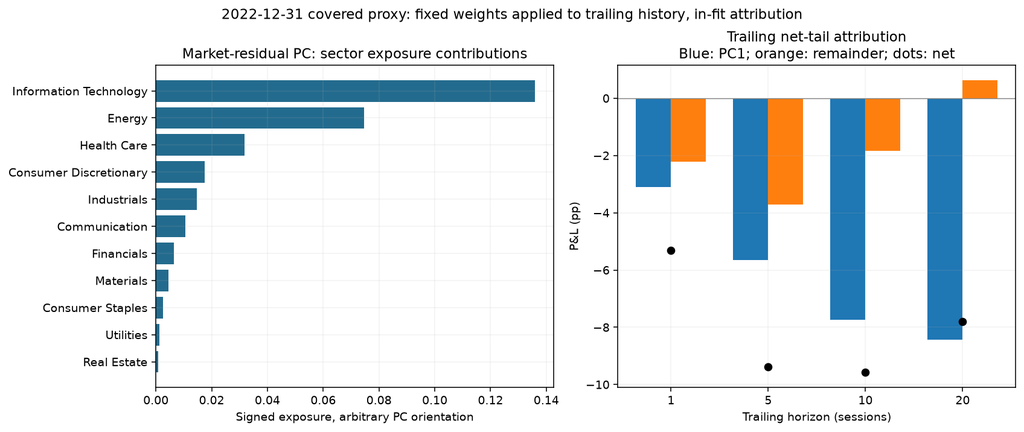

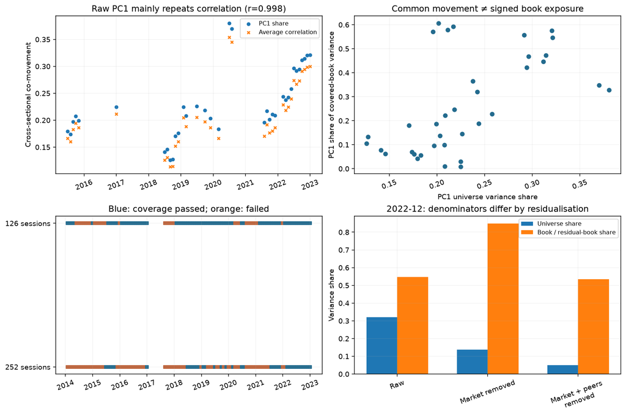

## E16. MTUM options audit and pricing proof of concept

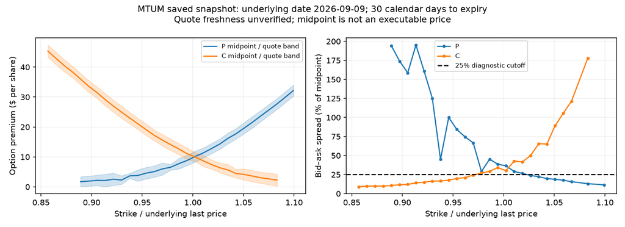

## E17. Recovery hazard specifications

**episode scores: 540 result rows**

| threshold | model | baseline | metric | episode | n | difference |
| --- | --- | --- | --- | --- | --- | --- |
| 5 | age | depth | brier | 11 | 160 | -3.8123e-06 |
| 5 | age | depth | brier | 12 | 52 | -3.39987e-05 |
| 5 | age | depth | brier | 13 | 44 | -5.4357e-06 |
| 5 | age | depth | brier | 14 | 9 | 0.00101445 |
| 5 | age | depth | brier | 15 | 92 | 0.000169452 |
| 5 | age | depth | brier | 16 | 8 | 0.0010479 |
| 5 | age | depth | brier | 17 | 3 | 0.000441723 |
| 5 | age | depth | brier | 18 | 25 | -2.3028e-06 |
| 5 | age | depth | brier | 19 | 55 | 0.000241707 |
| 5 | age | depth | brier | 20 | 18 | 3.75761e-05 |
| 5 | age | depth | brier | 21 | 28 | 2.64026e-05 |
| 5 | age | depth | brier | 22 | 268 | 4.08831e-05 |
| 5 | age | depth | brier | 23 | 17 | 0.000450206 |
| 5 | age | depth | brier | 24 | 17 | 6.1887e-06 |
| 5 | age | depth | brier | 25 | 735 | 6.81e-08 |
| 5 | age | depth | logloss | 11 | 160 | 0.00014367 |
| 5 | age | depth | logloss | 12 | 52 | -0.000113836 |
| 5 | age | depth | logloss | 13 | 44 | -0.000483452 |
| 5 | age | depth | logloss | 14 | 9 | -0.000538732 |
| 5 | age | depth | logloss | 15 | 92 | 0.000620492 |
| 5 | age | depth | logloss | 16 | 8 | 0.00316183 |
| 5 | age | depth | logloss | 17 | 3 | 0.00600733 |
| 5 | age | depth | logloss | 18 | 25 | -2.8018e-05 |
| 5 | age | depth | logloss | 19 | 55 | 0.000305513 |
| 5 | age | depth | logloss | 20 | 18 | 0.000465386 |
| 5 | age | depth | logloss | 21 | 28 | 0.000500624 |
| 5 | age | depth | logloss | 22 | 268 | 3.58549e-05 |
| 5 | age | depth | logloss | 23 | 17 | 0.00131475 |
| 5 | age | depth | logloss | 24 | 17 | 0.000111908 |
| 5 | age | depth | logloss | 25 | 735 | 3.42615e-05 |

[output cut: 510 more lines]

**inventory: 3 result rows**

| threshold | episodes | recoveries | censored | risk_weeks | test_weeks | test_recoveries | test_episodes | first_test | last_state |
| --- | --- | --- | --- | --- | --- | --- | --- | --- | --- |
| 5 | 25 | 24 | 1 | 2048 | 1531 | 14 | 15 | 1986-09-05 | {'active': True, 'episode': 25, 'depth': 40.030000000000655, 'age': 735, 'level': 304.32499999999897, 'peak': 344.3549999999996, 'event': 0} |
| 2.5 | 42 | 41 | 1 | 2159 | 1703 | 30 | 31 | 1984-01-06 | {'active': True, 'episode': 42, 'depth': 40.030000000000655, 'age': 735, 'level': 304.32499999999897, 'peak': 344.3549999999996, 'event': 0} |
| 10 | 18 | 17 | 1 | 1883 | 1151 | 7 | 8 | 1999-04-30 | {'active': True, 'episode': 18, 'depth': 40.030000000000655, 'age': 735, 'level': 304.32499999999897, 'peak': 344.3549999999996, 'event': 0} |

**pairs: 60 result rows**

| threshold | model | baseline | metric | block | difference | lo | hi | omit_longest |
| --- | --- | --- | --- | --- | --- | --- | --- | --- |
| 5 | age | depth | brier | 26 | 4.26051e-05 | 4.6034e-06 | 9.08697e-05 | 8.18822e-05 |
| 5 | age | depth | brier | 52 | 4.26051e-05 | 6.0139e-06 | 8.57512e-05 | 8.18822e-05 |
| 5 | age | depth | logloss | 26 | 0.000123377 | 2.334e-07 | 0.000274178 | 0.000205664 |
| 5 | age | depth | logloss | 52 | 0.000123377 | 6.259e-07 | 0.00027257 | 0.000205664 |
| 5 | full | exposure | brier | 26 | 2.67159e-05 | -7.8269e-06 | 6.57594e-05 | 5.11303e-05 |
| 5 | full | exposure | brier | 52 | 2.67159e-05 | -6.3709e-06 | 6.7881e-05 | 5.11303e-05 |
| 5 | full | exposure | logloss | 26 | 0.000133136 | -6.0467e-06 | 0.000282015 | 0.00017293 |
| 5 | full | exposure | logloss | 52 | 0.000133136 | -1.226e-07 | 0.000302367 | 0.00017293 |
| 5 | full | depth | brier | 26 | -6.37036e-05 | -0.00022166 | 6.67499e-05 | -0.000123698 |
| 5 | full | depth | brier | 52 | -6.37036e-05 | -0.000204601 | 5.79568e-05 | -0.000123698 |
| 5 | full | depth | logloss | 26 | -0.000433494 | -0.00125209 | 0.000205777 | -0.00102277 |
| 5 | full | depth | logloss | 52 | -0.000433494 | -0.0012581 | 0.000190197 | -0.00102277 |
| 5 | distance_age | distance | brier | 26 | -6.55929e-05 | -0.000272437 | 0.000101325 | -0.000125915 |
| 5 | distance_age | distance | brier | 52 | -6.55929e-05 | -0.000282051 | 0.000102108 | -0.000125915 |
| 5 | distance_age | distance | logloss | 26 | 9.45698e-05 | -0.000729791 | 0.000813055 | -0.000328774 |
| 5 | distance_age | distance | logloss | 52 | 9.45698e-05 | -0.000834482 | 0.000881492 | -0.000328774 |
| 5 | distance_full | distance_exposure | brier | 26 | -0.000118146 | -0.00035253 | 5.4788e-05 | -0.000228702 |
| 5 | distance_full | distance_exposure | brier | 52 | -0.000118146 | -0.000366833 | 6.87004e-05 | -0.000228702 |
| 5 | distance_full | distance_exposure | logloss | 26 | -3.1286e-05 | -0.00103546 | 0.000836228 | -0.000781366 |
| 5 | distance_full | distance_exposure | logloss | 52 | -3.1286e-05 | -0.00120956 | 0.000901841 | -0.000781366 |
| 2.5 | age | depth | brier | 26 | 4.70975e-05 | -3.83947e-05 | 0.000145116 | 8.30225e-05 |
| 2.5 | age | depth | brier | 52 | 4.70975e-05 | -2.76952e-05 | 0.000149768 | 8.30225e-05 |
| 2.5 | age | depth | logloss | 26 | 6.42218e-05 | -0.000156771 | 0.000319202 | 0.000199796 |
| 2.5 | age | depth | logloss | 52 | 6.42218e-05 | -0.000143553 | 0.000333512 | 0.000199796 |
| 2.5 | full | exposure | brier | 26 | 6.50272e-05 | -1.29012e-05 | 0.00015841 | 0.000114626 |
| 2.5 | full | exposure | brier | 52 | 6.50272e-05 | -5.2046e-06 | 0.000165014 | 0.000114626 |
| 2.5 | full | exposure | logloss | 26 | 0.000133586 | -6.97151e-05 | 0.000390947 | 0.000310539 |
| 2.5 | full | exposure | logloss | 52 | 0.000133586 | -7.79182e-05 | 0.000400776 | 0.000310539 |
| 2.5 | full | depth | brier | 26 | -4.99377e-05 | -0.000327261 | 0.000194114 | -8.84448e-05 |
| 2.5 | full | depth | brier | 52 | -4.99377e-05 | -0.000321299 | 0.000182129 | -8.84448e-05 |
| 2.5 | full | depth | logloss | 26 | -0.000246231 | -0.00117626 | 0.000535119 | -0.000434196 |
| 2.5 | full | depth | logloss | 52 | -0.000246231 | -0.00108172 | 0.000615037 | -0.000434196 |
| 2.5 | distance_age | distance | brier | 26 | 0.000101485 | -3.58646e-05 | 0.000287946 | 0.000178925 |
| 2.5 | distance_age | distance | brier | 52 | 0.000101485 | -3.11587e-05 | 0.000284616 | 0.000178925 |
| 2.5 | distance_age | distance | logloss | 26 | 0.000300559 | -0.000298609 | 0.000977542 | 0.000542796 |
| 2.5 | distance_age | distance | logloss | 52 | 0.000300559 | -0.000287038 | 0.000947485 | 0.000542796 |
| 2.5 | distance_full | distance_exposure | brier | 26 | 6.80343e-05 | -7.92557e-05 | 0.000259953 | 0.000116992 |
| 2.5 | distance_full | distance_exposure | brier | 52 | 6.80343e-05 | -7.92277e-05 | 0.000269128 | 0.000116992 |
| 2.5 | distance_full | distance_exposure | logloss | 26 | 0.000303059 | -0.000359522 | 0.00104818 | 0.000430825 |
| 2.5 | distance_full | distance_exposure | logloss | 52 | 0.000303059 | -0.00036688 | 0.00103985 | 0.000430825 |
| 10 | age | depth | brier | 26 | 3.21181e-05 | -5.3765e-06 | 0.000103076 | 8.83368e-05 |
| 10 | age | depth | brier | 52 | 3.21181e-05 | -3.6283e-06 | 0.000104172 | 8.83368e-05 |
| 10 | age | depth | logloss | 26 | 0.000120728 | -7.3903e-06 | 0.000324494 | 0.000133858 |
| 10 | age | depth | logloss | 52 | 0.000120728 | 7.605e-07 | 0.00031167 | 0.000133858 |
| 10 | full | exposure | brier | 26 | 3.60957e-05 | -6.436e-06 | 0.000118401 | 9.91655e-05 |
| 10 | full | exposure | brier | 52 | 3.60957e-05 | -5.7222e-06 | 0.000118341 | 9.91655e-05 |
| 10 | full | exposure | logloss | 26 | 0.000145996 | -1.0622e-06 | 0.000384023 | 0.000164864 |
| 10 | full | exposure | logloss | 52 | 0.000145996 | 3.1923e-06 | 0.000365028 | 0.000164864 |
| 10 | full | depth | brier | 26 | 0.000105167 | -6.76301e-05 | 0.000389949 | 0.000288777 |
| 10 | full | depth | brier | 52 | 0.000105167 | -6.36874e-05 | 0.000356053 | 0.000288777 |
| 10 | full | depth | logloss | 26 | 0.000128973 | -0.000712621 | 0.00100832 | -2.27191e-05 |
| 10 | full | depth | logloss | 52 | 0.000128973 | -0.000621763 | 0.000943754 | -2.27191e-05 |
| 10 | distance_age | distance | brier | 26 | -0.000103922 | -0.000366383 | 3.91939e-05 | -0.000284082 |
| 10 | distance_age | distance | brier | 52 | -0.000103922 | -0.000346277 | 3.06357e-05 | -0.000284082 |
| 10 | distance_age | distance | logloss | 26 | -1.99024e-05 | -0.000958249 | 0.000708782 | -0.00111098 |
| 10 | distance_age | distance | logloss | 52 | -1.99024e-05 | -0.00104497 | 0.000766062 | -0.00111098 |
| 10 | distance_full | distance_exposure | brier | 26 | -0.000133871 | -0.000441595 | 3.35242e-05 | -0.000356014 |
| 10 | distance_full | distance_exposure | brier | 52 | -0.000133871 | -0.000429269 | 2.90805e-05 | -0.000356014 |
| 10 | distance_full | distance_exposure | logloss | 26 | -0.000152913 | -0.0012432 | 0.000689093 | -0.00158539 |
| 10 | distance_full | distance_exposure | logloss | 52 | -0.000152913 | -0.00141461 | 0.000787307 | -0.00158539 |

**scores: 60 result rows**

| threshold | subset | model | n | events | brier | logloss | predicted | observed |
| --- | --- | --- | --- | --- | --- | --- | --- | --- |
| 5 | all | rate | 1531 | 14 | 0.00910077 | 0.0534551 | 0.0164452 | 0.00914435 |
| 5 | all | vol | 1531 | 14 | 0.00913032 | 0.0539383 | 0.0183464 | 0.00914435 |
| 5 | all | depth | 1531 | 14 | 0.00739101 | 0.0274378 | 0.0107917 | 0.00914435 |
| 5 | all | age | 1531 | 14 | 0.00743362 | 0.0275612 | 0.010777 | 0.00914435 |
| 5 | all | exposure | 1531 | 14 | 0.00730059 | 0.0268712 | 0.0107151 | 0.00914435 |
| 5 | all | full | 1531 | 14 | 0.00732731 | 0.0270043 | 0.0107732 | 0.00914435 |
| 5 | all | distance | 1531 | 14 | 0.00752747 | 0.0307823 | 0.013944 | 0.00914435 |
| 5 | all | distance_age | 1531 | 14 | 0.00746188 | 0.0308769 | 0.0142984 | 0.00914435 |
| 5 | all | distance_exposure | 1531 | 14 | 0.00745038 | 0.030555 | 0.013728 | 0.00914435 |
| 5 | all | distance_full | 1531 | 14 | 0.00733224 | 0.0305237 | 0.0141289 | 0.00914435 |
| 5 | 2017_2022 | rate | 312 | 0 | 0.000166557 | 0.012975 | 0.012891 | 0 |
| 5 | 2017_2022 | vol | 312 | 0 | 0.000195541 | 0.0140355 | 0.0139368 | 0 |
| 5 | 2017_2022 | depth | 312 | 0 | 8.88e-07 | 0.00085346 | 0.000853016 | 0 |
| 5 | 2017_2022 | age | 312 | 0 | 9.943e-07 | 0.000901401 | 0.000900903 | 0 |
| 5 | 2017_2022 | exposure | 312 | 0 | 1.1785e-06 | 0.000938125 | 0.000937535 | 0 |
| 5 | 2017_2022 | full | 312 | 0 | 1.5541e-06 | 0.00107163 | 0.00107085 | 0 |
| 5 | 2017_2022 | distance | 312 | 0 | 1.7633e-05 | 0.00281163 | 0.00280275 | 0 |
| 5 | 2017_2022 | distance_age | 312 | 0 | 3.67673e-05 | 0.00400062 | 0.00398207 | 0 |
| 5 | 2017_2022 | distance_exposure | 312 | 0 | 2.26116e-05 | 0.00308623 | 0.00307484 | 0 |
| 5 | 2017_2022 | distance_full | 312 | 0 | 5.38017e-05 | 0.00466407 | 0.00463685 | 0 |
| 2.5 | all | rate | 1703 | 30 | 0.0173519 | 0.0895763 | 0.0250457 | 0.017616 |
| 2.5 | all | vol | 1703 | 30 | 0.0174357 | 0.0905541 | 0.0288219 | 0.017616 |
| 2.5 | all | depth | 1703 | 30 | 0.0125456 | 0.0440707 | 0.0181152 | 0.017616 |
| 2.5 | all | age | 1703 | 30 | 0.0125927 | 0.044135 | 0.0179113 | 0.017616 |
| 2.5 | all | exposure | 1703 | 30 | 0.0124307 | 0.0436909 | 0.0174289 | 0.017616 |
| 2.5 | all | full | 1703 | 30 | 0.0124957 | 0.0438245 | 0.0173354 | 0.017616 |
| 2.5 | all | distance | 1703 | 30 | 0.0131737 | 0.0482849 | 0.0200716 | 0.017616 |
| 2.5 | all | distance_age | 1703 | 30 | 0.0132752 | 0.0485854 | 0.0200478 | 0.017616 |
| 2.5 | all | distance_exposure | 1703 | 30 | 0.0131279 | 0.0481039 | 0.0190105 | 0.017616 |
| 2.5 | all | distance_full | 1703 | 30 | 0.013196 | 0.048407 | 0.0190434 | 0.017616 |
| 2.5 | 2017_2022 | rate | 312 | 0 | 0.000432707 | 0.021 | 0.0207806 | 0 |
| 2.5 | 2017_2022 | vol | 312 | 0 | 0.000563474 | 0.0238488 | 0.0235624 | 0 |
| 2.5 | 2017_2022 | depth | 312 | 0 | 8.698e-07 | 0.000810366 | 0.000809931 | 0 |
| 2.5 | 2017_2022 | age | 312 | 0 | 4.77e-07 | 0.000607906 | 0.000607668 | 0 |
| 2.5 | 2017_2022 | exposure | 312 | 0 | 1.1249e-06 | 0.000890026 | 0.000889463 | 0 |
| 2.5 | 2017_2022 | full | 312 | 0 | 7.081e-07 | 0.000714108 | 0.000713754 | 0 |
| 2.5 | 2017_2022 | distance | 312 | 0 | 1.83678e-05 | 0.00268685 | 0.0026776 | 0 |
| 2.5 | 2017_2022 | distance_age | 312 | 0 | 1.7877e-05 | 0.00263834 | 0.00262934 | 0 |
| 2.5 | 2017_2022 | distance_exposure | 312 | 0 | 2.32998e-05 | 0.00296602 | 0.00295427 | 0 |
| 2.5 | 2017_2022 | distance_full | 312 | 0 | 2.70643e-05 | 0.00316692 | 0.00315327 | 0 |
| 10 | all | rate | 1151 | 7 | 0.0060777 | 0.0387004 | 0.012667 | 0.00608167 |
| 10 | all | vol | 1151 | 7 | 0.0061092 | 0.0393476 | 0.0153339 | 0.00608167 |
| 10 | all | depth | 1151 | 7 | 0.00562037 | 0.019774 | 0.00574218 | 0.00608167 |
| 10 | all | age | 1151 | 7 | 0.00565249 | 0.0198947 | 0.0058061 | 0.00608167 |
| 10 | all | exposure | 1151 | 7 | 0.00568945 | 0.019757 | 0.00621671 | 0.00608167 |
| 10 | all | full | 1151 | 7 | 0.00572554 | 0.019903 | 0.00631086 | 0.00608167 |
| 10 | all | distance | 1151 | 7 | 0.00531569 | 0.0224674 | 0.0102801 | 0.00608167 |
| 10 | all | distance_age | 1151 | 7 | 0.00521177 | 0.0224475 | 0.0101474 | 0.00608167 |
| 10 | all | distance_exposure | 1151 | 7 | 0.00532718 | 0.0228824 | 0.0113876 | 0.00608167 |
| 10 | all | distance_full | 1151 | 7 | 0.00519331 | 0.0227295 | 0.0111338 | 0.00608167 |
| 10 | 2017_2022 | rate | 312 | 0 | 0.000100707 | 0.0100722 | 0.0100215 | 0 |
| 10 | 2017_2022 | vol | 312 | 0 | 0.000136142 | 0.0116304 | 0.0115618 | 0 |
| 10 | 2017_2022 | depth | 312 | 0 | 1.5581e-06 | 0.00113733 | 0.00113655 | 0 |
| 10 | 2017_2022 | age | 312 | 0 | 2.0419e-06 | 0.00129671 | 0.00129569 | 0 |
| 10 | 2017_2022 | exposure | 312 | 0 | 1.7446e-06 | 0.00116819 | 0.00116732 | 0 |
| 10 | 2017_2022 | full | 312 | 0 | 2.3767e-06 | 0.00135734 | 0.00135615 | 0 |
| 10 | 2017_2022 | distance | 312 | 0 | 1.88397e-05 | 0.00305003 | 0.00304055 | 0 |
| 10 | 2017_2022 | distance_age | 312 | 0 | 3.92298e-05 | 0.00434057 | 0.00432078 | 0 |
| 10 | 2017_2022 | distance_exposure | 312 | 0 | 2.19115e-05 | 0.00321841 | 0.00320738 | 0 |
| 10 | 2017_2022 | distance_full | 312 | 0 | 4.77291e-05 | 0.00467228 | 0.00464817 | 0 |

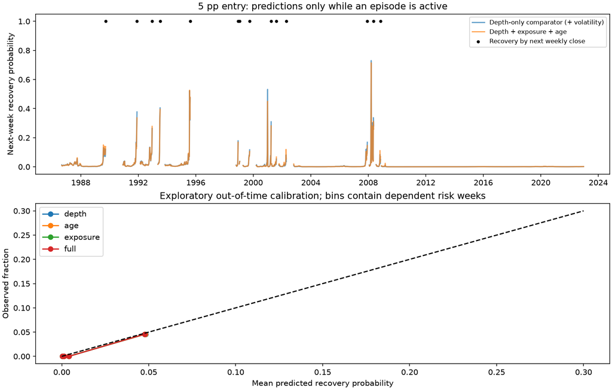

## E18. Local stress transitions and first passage

**inventory: 8 result rows**

| test | n | events | exits_with_nonpositive_next_week | terminal_events | breached_but_recovered |
| --- | --- | --- | --- | --- | --- |
| state_4_1.5_onset | 1837 | 53 | NaN | NaN | NaN |
| state_4_1.5_exit | 197 | 54 | 9 | NaN | NaN |
| state_4_2_onset | 1449 | 17 | NaN | NaN | NaN |
| state_4_2_exit | 63 | 17 | 1 | NaN | NaN |
| state_2_1.5_onset | 1826 | 86 | NaN | NaN | NaN |
| state_2_1.5_exit | 185 | 78 | 11 | NaN | NaN |
| barrier_fixed | 2030 | 244 | NaN | 149 | 95 |
| barrier_scaled | 2030 | 146 | NaN | 94 | 52 |

**latest path assessment: 2 result rows**

| date | target | barrier_pp | completed_paths | path_breach_probability | terminal_breach_probability | average_path_low_given_breach | note |
| --- | --- | --- | --- | --- | --- | --- | --- |
| 2022-12-30 | barrier_fixed | -5 | 1260 | 0.353291 | 0.196273 | -10.3444 | Filtered historical simulation, descriptive prototype; path rescaling and overlapping histories limit calibration. |
| 2022-12-30 | barrier_scaled | -13.5977 | 1260 | 0.0701824 | 0.0448057 | -18.8868 | Filtered historical simulation, descriptive prototype; path rescaling and overlapping histories limit calibration. |

**pairs: 392 result rows**

| test | subset | model | baseline | metric | block | difference | lo | hi |
| --- | --- | --- | --- | --- | --- | --- | --- | --- |
| state_4_1.5_onset | all | age | mechanical | brier | 26 | 0.000359322 | -5.48994e-05 | 0.000864483 |
| state_4_1.5_onset | all | age | mechanical | brier | 52 | 0.000359322 | -0.000113797 | 0.000864427 |
| state_4_1.5_onset | recent | age | mechanical | brier | 26 | 1.49193e-05 | -0.00023189 | 0.00028656 |
| state_4_1.5_onset | recent | age | mechanical | brier | 52 | 1.49193e-05 | -0.000187277 | 0.00027704 |
| state_4_1.5_onset | exclude_crises | age | mechanical | brier | 26 | 0.000412053 | -3.358e-05 | 0.000939184 |
| state_4_1.5_onset | exclude_crises | age | mechanical | brier | 52 | 0.000412053 | -9.93901e-05 | 0.00096241 |
| state_4_1.5_onset | all | age | mechanical | logloss | 26 | 0.00161152 | -3.72817e-05 | 0.0035069 |
| state_4_1.5_onset | all | age | mechanical | logloss | 52 | 0.00161152 | -0.000414564 | 0.00380452 |
| state_4_1.5_onset | recent | age | mechanical | logloss | 26 | 3.38887e-05 | -0.0013175 | 0.0015168 |
| state_4_1.5_onset | recent | age | mechanical | logloss | 52 | 3.38887e-05 | -0.00132186 | 0.0014889 |
| state_4_1.5_onset | exclude_crises | age | mechanical | logloss | 26 | 0.00183707 | 0.000120657 | 0.0037309 |
| state_4_1.5_onset | exclude_crises | age | mechanical | logloss | 52 | 0.00183707 | -0.000374771 | 0.00413439 |
| state_4_1.5_onset | all | exposure | mechanical | brier | 26 | 0.000235638 | -0.00050933 | 0.0010507 |
| state_4_1.5_onset | all | exposure | mechanical | brier | 52 | 0.000235638 | -0.000535376 | 0.00116088 |
| state_4_1.5_onset | recent | exposure | mechanical | brier | 26 | 0.000178572 | -0.000486199 | 0.000915964 |
| state_4_1.5_onset | recent | exposure | mechanical | brier | 52 | 0.000178572 | -0.000456293 | 0.000892212 |
| state_4_1.5_onset | exclude_crises | exposure | mechanical | brier | 26 | 0.00021299 | -0.000517752 | 0.00112536 |
| state_4_1.5_onset | exclude_crises | exposure | mechanical | brier | 52 | 0.00021299 | -0.000629101 | 0.00124974 |
| state_4_1.5_onset | all | exposure | mechanical | logloss | 26 | 0.000672917 | -0.00216759 | 0.00354372 |
| state_4_1.5_onset | all | exposure | mechanical | logloss | 52 | 0.000672917 | -0.00212562 | 0.00432388 |
| state_4_1.5_onset | recent | exposure | mechanical | logloss | 26 | -0.0002275 | -0.00340551 | 0.00287823 |
| state_4_1.5_onset | recent | exposure | mechanical | logloss | 52 | -0.0002275 | -0.00337351 | 0.00312967 |
| state_4_1.5_onset | exclude_crises | exposure | mechanical | logloss | 26 | -4.50549e-05 | -0.00316038 | 0.00313591 |
| state_4_1.5_onset | exclude_crises | exposure | mechanical | logloss | 52 | -4.50549e-05 | -0.00323525 | 0.00393654 |
| state_4_1.5_onset | all | shape | mechanical | brier | 26 | 0.000228681 | 8.6601e-06 | 0.000516326 |
| state_4_1.5_onset | all | shape | mechanical | brier | 52 | 0.000228681 | 9.274e-06 | 0.000486383 |
| state_4_1.5_onset | recent | shape | mechanical | brier | 26 | 0.000123577 | -0.000170563 | 0.000491997 |
| state_4_1.5_onset | recent | shape | mechanical | brier | 52 | 0.000123577 | -0.000159904 | 0.000509628 |
| state_4_1.5_onset | exclude_crises | shape | mechanical | brier | 26 | 0.000252508 | 1.66613e-05 | 0.000566653 |
| state_4_1.5_onset | exclude_crises | shape | mechanical | brier | 52 | 0.000252508 | 2.52548e-05 | 0.00052005 |

[output cut: 362 more lines]

**scores: 1883 result rows**

| test | subset | model | n | events | brier | logloss | predicted | observed |
| --- | --- | --- | --- | --- | --- | --- | --- | --- |
| state_4_1.5_onset | all | rate | 1837 | 53 | 0.0282374 | 0.133499 | 0.0439509 | 0.0288514 |
| state_4_1.5_onset | all | vol | 1837 | 53 | 0.0281877 | 0.133254 | 0.0499304 | 0.0288514 |
| state_4_1.5_onset | all | mechanical | 1837 | 53 | 0.0207885 | 0.0850573 | 0.0473991 | 0.0288514 |
| state_4_1.5_onset | all | age | 1837 | 53 | 0.0211478 | 0.0866688 | 0.0496992 | 0.0288514 |
| state_4_1.5_onset | all | exposure | 1837 | 53 | 0.0210241 | 0.0857302 | 0.0478562 | 0.0288514 |
| state_4_1.5_onset | all | shape | 1837 | 53 | 0.0210172 | 0.0857954 | 0.047685 | 0.0288514 |
| state_4_1.5_onset | all | full | 1837 | 53 | 0.021676 | 0.0883217 | 0.0508395 | 0.0288514 |
| state_4_1.5_onset | recent | rate | 294 | 6 | 0.0202444 | 0.103896 | 0.0357018 | 0.0204082 |
| state_4_1.5_onset | recent | vol | 294 | 6 | 0.0203308 | 0.105225 | 0.0434139 | 0.0204082 |
| state_4_1.5_onset | recent | mechanical | 294 | 6 | 0.016816 | 0.0705363 | 0.031706 | 0.0204082 |
| state_4_1.5_onset | recent | age | 294 | 6 | 0.0168309 | 0.0705702 | 0.0312873 | 0.0204082 |
| state_4_1.5_onset | recent | exposure | 294 | 6 | 0.0169946 | 0.0703088 | 0.0288244 | 0.0204082 |
| state_4_1.5_onset | recent | shape | 294 | 6 | 0.0169396 | 0.0708135 | 0.0312903 | 0.0204082 |
| state_4_1.5_onset | recent | full | 294 | 6 | 0.0172262 | 0.0712385 | 0.0286602 | 0.0204082 |
| state_4_1.5_onset | exclude_crises | rate | 1705 | 46 | 0.0265214 | 0.127609 | 0.0443721 | 0.0269795 |
| state_4_1.5_onset | exclude_crises | vol | 1705 | 46 | 0.0265548 | 0.128164 | 0.0490743 | 0.0269795 |
| state_4_1.5_onset | exclude_crises | mechanical | 1705 | 46 | 0.0203669 | 0.0836155 | 0.0467561 | 0.0269795 |
| state_4_1.5_onset | exclude_crises | age | 1705 | 46 | 0.020779 | 0.0854526 | 0.0493261 | 0.0269795 |
| state_4_1.5_onset | exclude_crises | exposure | 1705 | 46 | 0.0205799 | 0.0835705 | 0.0461206 | 0.0269795 |
| state_4_1.5_onset | exclude_crises | shape | 1705 | 46 | 0.0206194 | 0.0844272 | 0.0470294 | 0.0269795 |
| state_4_1.5_onset | exclude_crises | full | 1705 | 46 | 0.0213536 | 0.0865382 | 0.0493129 | 0.0269795 |
| state_4_1.5_onset | 1984 | rate | 44 | 1 | 0.0235858 | 0.124284 | 0.0598086 | 0.0227273 |
| state_4_1.5_onset | 1984 | vol | 44 | 1 | 0.023087 | 0.120047 | 0.0594573 | 0.0227273 |
| state_4_1.5_onset | 1984 | mechanical | 44 | 1 | 0.0111478 | 0.0584924 | 0.0449819 | 0.0227273 |
| state_4_1.5_onset | 1984 | age | 44 | 1 | 0.0101135 | 0.0561253 | 0.0472573 | 0.0227273 |
| state_4_1.5_onset | 1984 | exposure | 44 | 1 | 0.0104141 | 0.0583116 | 0.0475659 | 0.0227273 |
| state_4_1.5_onset | 1984 | shape | 44 | 1 | 0.0132746 | 0.056833 | 0.0338686 | 0.0227273 |
| state_4_1.5_onset | 1984 | full | 44 | 1 | 0.0111658 | 0.0526774 | 0.0374735 | 0.0227273 |
| state_4_1.5_onset | 1985 | rate | 42 | 2 | 0.0454264 | 0.192187 | 0.0562771 | 0.047619 |
| state_4_1.5_onset | 1985 | vol | 42 | 2 | 0.0448605 | 0.186476 | 0.0500835 | 0.047619 |

[output cut: 1853 more lines]

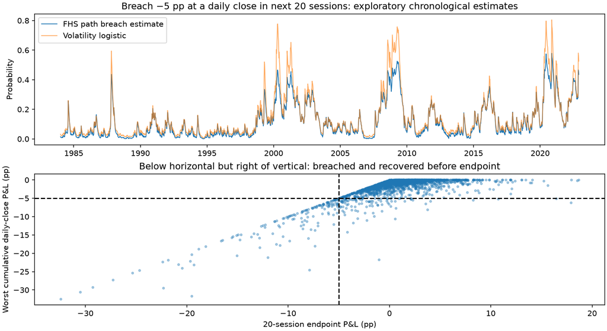

## E20. Frozen recent-period validation

**pairs: 16 result rows**

| component | model | baseline | metric | block | difference | lo | hi |
| --- | --- | --- | --- | --- | --- | --- | --- |
| weekly | p_fhs5y_ewma | p_logit_ewma | brier | 13 | 0.000776949 | -0.00163051 | 0.00426194 |
| weekly | p_fhs5y_ewma | p_logit_ewma | brier | 26 | 0.000776949 | -0.00134649 | 0.00363875 |
| weekly | p_fhs5y_ewma | p_logit_ewma | logloss | 13 | 0.00229304 | -0.00495732 | 0.013009 |
| weekly | p_fhs5y_ewma | p_logit_ewma | logloss | 26 | 0.00229304 | -0.00433287 | 0.0112381 |
| path | p_fhs | p_vol | brier | 13 | 0.000840597 | -0.000721023 | 0.00284765 |
| path | p_fhs | p_vol | brier | 26 | 0.000840597 | -0.000577897 | 0.00236265 |
| path | p_fhs | p_vol | logloss | 13 | 0.00192015 | -0.00254169 | 0.00687568 |
| path | p_fhs | p_vol | logloss | 26 | 0.00192015 | -0.0021816 | 0.00604429 |
| conditional | rolling | dynamic | mae | 13 | -0.0293748 | -0.0585299 | -0.00728349 |
| conditional | rolling | dynamic | mae | 26 | -0.0293748 | -0.0605759 | -0.00104431 |
| conditional | rolling | dynamic | mse | 13 | -0.0709113 | -0.184381 | 0.0332608 |
| conditional | rolling | dynamic | mse | 26 | -0.0709113 | -0.180953 | 0.0443545 |
| conditional | dynamic | vol_response | mae | 13 | -0.0123342 | -0.0816422 | 0.0606258 |
| conditional | dynamic | vol_response | mae | 26 | -0.0123342 | -0.095305 | 0.0721199 |
| conditional | dynamic | vol_response | mse | 13 | 0.00414529 | -0.342515 | 0.363062 |
| conditional | dynamic | vol_response | mse | 26 | 0.00414529 | -0.366417 | 0.343387 |

**scores: 40 result rows**

| component | period | model | n | first | last | events | predicted | observed | brier | logloss | q05_breaches | q05_breach_rate | pinball | bear_weeks | bear_events | endpoint_events | recovered | mae | mse |
| --- | --- | --- | --- | --- | --- | --- | --- | --- | --- | --- | --- | --- | --- | --- | --- | --- | --- | --- | --- |
| weekly | 2023+ | p_fhs5y_ewma | 186 | 2023-01-06 | 2026-07-24 | 23 | 0.131731 | 0.123656 | 0.104425 | 0.356248 | 4 | 0.0215054 | 0.197668 | 33 | 6 | NaN | NaN | NaN | NaN |
| weekly | 2023+ | p_logit_ewma | 186 | 2023-01-06 | 2026-07-24 | 23 | 0.141502 | 0.123656 | 0.103648 | 0.353955 | NaN | NaN | NaN | NaN | NaN | NaN | NaN | NaN | NaN |
| weekly | 2023+ | p_frequency | 186 | 2023-01-06 | 2026-07-24 | 23 | 0.0845289 | 0.123656 | 0.110003 | 0.383599 | NaN | NaN | NaN | NaN | NaN | NaN | NaN | NaN | NaN |
| weekly | 2023 | p_fhs5y_ewma | 52 | 2023-01-06 | 2023-12-29 | 10 | 0.125479 | 0.192308 | 0.152174 | 0.473775 | 1 | 0.0192308 | 0.172446 | 32 | 6 | NaN | NaN | NaN | NaN |
| weekly | 2023 | p_logit_ewma | 52 | 2023-01-06 | 2023-12-29 | 10 | 0.145883 | 0.192308 | 0.148786 | 0.462749 | NaN | NaN | NaN | NaN | NaN | NaN | NaN | NaN | NaN |
| weekly | 2023 | p_frequency | 52 | 2023-01-06 | 2023-12-29 | 10 | 0.0833333 | 0.192308 | 0.167201 | 0.548145 | NaN | NaN | NaN | NaN | NaN | NaN | NaN | NaN | NaN |
| weekly | 2024 | p_fhs5y_ewma | 52 | 2024-01-05 | 2024-12-27 | 1 | 0.105364 | 0.0192308 | 0.0260964 | 0.148609 | 0 | 0 | 0.159881 | 1 | 0 | NaN | NaN | NaN | NaN |
| weekly | 2024 | p_logit_ewma | 52 | 2024-01-05 | 2024-12-27 | 1 | 0.101506 | 0.0192308 | 0.0254298 | 0.145941 | NaN | NaN | NaN | NaN | NaN | NaN | NaN | NaN | NaN |
| weekly | 2024 | p_frequency | 52 | 2024-01-05 | 2024-12-27 | 1 | 0.0855061 | 0.0192308 | 0.0232534 | 0.134957 | NaN | NaN | NaN | NaN | NaN | NaN | NaN | NaN | NaN |
| weekly | 2025 | p_fhs5y_ewma | 52 | 2025-01-03 | 2025-12-26 | 8 | 0.132552 | 0.153846 | 0.131476 | 0.435204 | 3 | 0.0576923 | 0.232124 | 0 | 0 | NaN | NaN | NaN | NaN |
| weekly | 2025 | p_logit_ewma | 52 | 2025-01-03 | 2025-12-26 | 8 | 0.139187 | 0.153846 | 0.132957 | 0.440414 | NaN | NaN | NaN | NaN | NaN | NaN | NaN | NaN | NaN |
| weekly | 2025 | p_frequency | 52 | 2025-01-03 | 2025-12-26 | 8 | 0.0842044 | 0.153846 | 0.135035 | 0.455174 | NaN | NaN | NaN | NaN | NaN | NaN | NaN | NaN | NaN |
| weekly | 2026 | p_fhs5y_ewma | 30 | 2026-01-02 | 2026-07-24 | 4 | 0.186845 | 0.133333 | 0.110543 | 0.375587 | 0 | 0 | 0.247163 | 0 | 0 | NaN | NaN | NaN | NaN |
| weekly | 2026 | p_logit_ewma | 30 | 2026-01-02 | 2026-07-24 | 4 | 0.207249 | 0.133333 | 0.110188 | 0.376075 | NaN | NaN | NaN | NaN | NaN | NaN | NaN | NaN | NaN |
| weekly | 2026 | p_frequency | 30 | 2026-01-02 | 2026-07-24 | 4 | 0.0854697 | 0.133333 | 0.117835 | 0.405302 | NaN | NaN | NaN | NaN | NaN | NaN | NaN | NaN | NaN |
| path | 2023+ | p_fhs | 183 | 2023-01-06 | 2026-07-03 | 17 | 0.195861 | 0.0928962 | 0.0879384 | 0.322307 | NaN | NaN | NaN | NaN | NaN | 8 | 9 | NaN | NaN |
| path | 2023+ | p_vol | 183 | 2023-01-06 | 2026-07-03 | 17 | 0.194789 | 0.0928962 | 0.0870978 | 0.320387 | NaN | NaN | NaN | NaN | NaN | 8 | 9 | NaN | NaN |
| path | 2023 | p_fhs | 52 | 2023-01-06 | 2023-12-29 | 9 | 0.202312 | 0.173077 | 0.133197 | 0.423759 | NaN | NaN | NaN | NaN | NaN | 5 | 4 | NaN | NaN |
| path | 2023 | p_vol | 52 | 2023-01-06 | 2023-12-29 | 9 | 0.203061 | 0.173077 | 0.133649 | 0.425212 | NaN | NaN | NaN | NaN | NaN | 5 | 4 | NaN | NaN |
| path | 2024 | p_fhs | 52 | 2024-01-05 | 2024-12-27 | 0 | 0.14221 | 0 | 0.0217191 | 0.154406 | NaN | NaN | NaN | NaN | NaN | 0 | 0 | NaN | NaN |
| path | 2024 | p_vol | 52 | 2024-01-05 | 2024-12-27 | 0 | 0.140689 | 0 | 0.0207801 | 0.15229 | NaN | NaN | NaN | NaN | NaN | 0 | 0 | NaN | NaN |
| path | 2025 | p_fhs | 52 | 2025-01-03 | 2025-12-26 | 5 | 0.202861 | 0.0961538 | 0.0996521 | 0.360085 | NaN | NaN | NaN | NaN | NaN | 2 | 3 | NaN | NaN |
| path | 2025 | p_vol | 52 | 2025-01-03 | 2025-12-26 | 5 | 0.196467 | 0.0961538 | 0.0990001 | 0.357966 | NaN | NaN | NaN | NaN | NaN | 2 | 3 | NaN | NaN |
| path | 2026 | p_fhs | 27 | 2026-01-02 | 2026-07-03 | 3 | 0.273284 | 0.111111 | 0.105748 | 0.377523 | NaN | NaN | NaN | NaN | NaN | 1 | 2 | NaN | NaN |
| path | 2026 | p_vol | 27 | 2026-01-02 | 2026-07-03 | 3 | 0.279821 | 0.111111 | 0.102243 | 0.369866 | NaN | NaN | NaN | NaN | NaN | 1 | 2 | NaN | NaN |
| conditional | 2023+ | rolling | 187 | 2023-01-06 | 2026-07-31 | NaN | NaN | NaN | NaN | NaN | NaN | NaN | NaN | NaN | NaN | NaN | NaN | 1.59642 | 4.06488 |
| conditional | 2023+ | dynamic | 187 | 2023-01-06 | 2026-07-31 | NaN | NaN | NaN | NaN | NaN | NaN | NaN | NaN | NaN | NaN | NaN | NaN | 1.62579 | 4.13579 |
| conditional | 2023+ | vol_response | 187 | 2023-01-06 | 2026-07-31 | NaN | NaN | NaN | NaN | NaN | NaN | NaN | NaN | NaN | NaN | NaN | NaN | 1.63813 | 4.13165 |
| conditional | 2023 | rolling | 52 | 2023-01-06 | 2023-12-29 | NaN | NaN | NaN | NaN | NaN | NaN | NaN | NaN | NaN | NaN | NaN | NaN | 1.53755 | 3.64968 |
| conditional | 2023 | dynamic | 52 | 2023-01-06 | 2023-12-29 | NaN | NaN | NaN | NaN | NaN | NaN | NaN | NaN | NaN | NaN | NaN | NaN | 1.55623 | 3.7451 |
| conditional | 2023 | vol_response | 52 | 2023-01-06 | 2023-12-29 | NaN | NaN | NaN | NaN | NaN | NaN | NaN | NaN | NaN | NaN | NaN | NaN | 1.55044 | 3.88763 |
| conditional | 2024 | rolling | 52 | 2024-01-05 | 2024-12-27 | NaN | NaN | NaN | NaN | NaN | NaN | NaN | NaN | NaN | NaN | NaN | NaN | 1.36997 | 2.95718 |
| conditional | 2024 | dynamic | 52 | 2024-01-05 | 2024-12-27 | NaN | NaN | NaN | NaN | NaN | NaN | NaN | NaN | NaN | NaN | NaN | NaN | 1.44156 | 3.18287 |
| conditional | 2024 | vol_response | 52 | 2024-01-05 | 2024-12-27 | NaN | NaN | NaN | NaN | NaN | NaN | NaN | NaN | NaN | NaN | NaN | NaN | 1.43969 | 3.11931 |
| conditional | 2025 | rolling | 52 | 2025-01-03 | 2025-12-26 | NaN | NaN | NaN | NaN | NaN | NaN | NaN | NaN | NaN | NaN | NaN | NaN | 1.65082 | 4.46303 |
| conditional | 2025 | dynamic | 52 | 2025-01-03 | 2025-12-26 | NaN | NaN | NaN | NaN | NaN | NaN | NaN | NaN | NaN | NaN | NaN | NaN | 1.68578 | 4.49833 |
| conditional | 2025 | vol_response | 52 | 2025-01-03 | 2025-12-26 | NaN | NaN | NaN | NaN | NaN | NaN | NaN | NaN | NaN | NaN | NaN | NaN | 1.70506 | 4.33198 |
| conditional | 2026 | rolling | 31 | 2026-01-02 | 2026-07-31 | NaN | NaN | NaN | NaN | NaN | NaN | NaN | NaN | NaN | NaN | NaN | NaN | 1.98375 | 5.95158 |
| conditional | 2026 | dynamic | 31 | 2026-01-02 | 2026-07-31 | NaN | NaN | NaN | NaN | NaN | NaN | NaN | NaN | NaN | NaN | NaN | NaN | 1.95088 | 5.78147 |
| conditional | 2026 | vol_response | 31 | 2026-01-02 | 2026-07-31 | NaN | NaN | NaN | NaN | NaN | NaN | NaN | NaN | NaN | NaN | NaN | NaN | 2.0058 | 5.90304 |

## E21. GARCH simulations of interim loss

**pairs: 90 result rows**

| subset | model | baseline | metric | block | difference | lo | hi |
| --- | --- | --- | --- | --- | --- | --- | --- |
| 1984_2022 | p_garch_t | p_fhs | brier | 13 | 0.000510167 | -0.00152366 | 0.00284442 |
| 1984_2022 | p_garch_t | p_fhs | brier | 26 | 0.000510167 | -0.00155613 | 0.00266281 |
| 1984_2022 | p_garch_t | p_fhs | brier | 52 | 0.000510167 | -0.00156719 | 0.00280109 |
| 1984_2022 | p_garch_t | p_fhs | logloss | 13 | 0.0074745 | -0.00284793 | 0.0196356 |
| 1984_2022 | p_garch_t | p_fhs | logloss | 26 | 0.0074745 | -0.00274501 | 0.0194642 |
| 1984_2022 | p_garch_t | p_fhs | logloss | 52 | 0.0074745 | -0.0032105 | 0.0194976 |
| 1984_2022 | p_garch_t | p_vol | brier | 13 | 0.000124445 | -0.00317925 | 0.00335117 |
| 1984_2022 | p_garch_t | p_vol | brier | 26 | 0.000124445 | -0.00320545 | 0.0032103 |
| 1984_2022 | p_garch_t | p_vol | brier | 52 | 0.000124445 | -0.00281574 | 0.00329518 |
| 1984_2022 | p_garch_t | p_vol | logloss | 13 | 0.00275044 | -0.0103356 | 0.0170844 |
| 1984_2022 | p_garch_t | p_vol | logloss | 26 | 0.00275044 | -0.0110236 | 0.01622 |
| 1984_2022 | p_garch_t | p_vol | logloss | 52 | 0.00275044 | -0.00998505 | 0.0171912 |
| 1984_2022 | p_garch_t | p_constant_t | brier | 13 | 0.000622357 | -0.000523123 | 0.00192287 |
| 1984_2022 | p_garch_t | p_constant_t | brier | 26 | 0.000622357 | -0.00050639 | 0.001781 |
| 1984_2022 | p_garch_t | p_constant_t | brier | 52 | 0.000622357 | -0.000371004 | 0.001841 |
| 1984_2022 | p_garch_t | p_constant_t | logloss | 13 | -0.00693817 | -0.0153903 | 0.000818543 |
| 1984_2022 | p_garch_t | p_constant_t | logloss | 26 | -0.00693817 | -0.0153807 | 0.000652651 |
| 1984_2022 | p_garch_t | p_constant_t | logloss | 52 | -0.00693817 | -0.015785 | 0.000647298 |
| 1984_2022 | p_gjr_t | p_fhs | brier | 13 | 0.000466079 | -0.00159919 | 0.00286537 |
| 1984_2022 | p_gjr_t | p_fhs | brier | 26 | 0.000466079 | -0.00164023 | 0.00269041 |
| 1984_2022 | p_gjr_t | p_fhs | brier | 52 | 0.000466079 | -0.00166502 | 0.00282958 |
| 1984_2022 | p_gjr_t | p_fhs | logloss | 13 | 0.00740272 | -0.00318915 | 0.0197097 |
| 1984_2022 | p_gjr_t | p_fhs | logloss | 26 | 0.00740272 | -0.00299156 | 0.0194327 |
| 1984_2022 | p_gjr_t | p_fhs | logloss | 52 | 0.00740272 | -0.00350077 | 0.019708 |
| 1984_2022 | p_gjr_t | p_garch_t | brier | 13 | -4.40882e-05 | -0.000147405 | 7.09726e-05 |
| 1984_2022 | p_gjr_t | p_garch_t | brier | 26 | -4.40882e-05 | -0.000143887 | 6.71244e-05 |
| 1984_2022 | p_gjr_t | p_garch_t | brier | 52 | -4.40882e-05 | -0.000145777 | 6.01004e-05 |
| 1984_2022 | p_gjr_t | p_garch_t | logloss | 13 | -7.17775e-05 | -0.000652942 | 0.000577534 |
| 1984_2022 | p_gjr_t | p_garch_t | logloss | 26 | -7.17775e-05 | -0.000591106 | 0.000522685 |
| 1984_2022 | p_gjr_t | p_garch_t | logloss | 52 | -7.17775e-05 | -0.000574856 | 0.000456608 |

[output cut: 60 more lines]

**scores: 230 result rows**

| subset | model | n | events | predicted | observed | brier | logloss | endpoint_predicted | endpoint_observed | endpoint_brier | endpoint_logloss |
| --- | --- | --- | --- | --- | --- | --- | --- | --- | --- | --- | --- |
| 1984_2022 | p_fhs | 2030 | 244 | 0.117517 | 0.120197 | 0.0858244 | 0.28328 | NaN | NaN | NaN | NaN |
| 1984_2022 | p_vol | 2030 | 244 | 0.142058 | 0.120197 | 0.0862102 | 0.288004 | NaN | NaN | NaN | NaN |
| 1984_2022 | p_garch_t | 2030 | 244 | 0.0895143 | 0.120197 | 0.0863346 | 0.290755 | 0.0544935 | 0.073399 | 0.0615056 | 0.225077 |
| 1984_2022 | p_gjr_t | 2030 | 244 | 0.0890766 | 0.120197 | 0.0862905 | 0.290683 | 0.0544561 | 0.073399 | 0.0615432 | 0.225275 |
| 1984_2022 | p_constant_t | 2030 | 244 | 0.0959745 | 0.120197 | 0.0857123 | 0.297693 | 0.0589483 | 0.073399 | 0.0613034 | 0.230098 |
| 2023_plus | p_fhs | 183 | 17 | 0.195861 | 0.0928962 | 0.0879384 | 0.322307 | NaN | NaN | NaN | NaN |
| 2023_plus | p_vol | 183 | 17 | 0.194789 | 0.0928962 | 0.0870978 | 0.320387 | NaN | NaN | NaN | NaN |
| 2023_plus | p_garch_t | 183 | 17 | 0.166707 | 0.0928962 | 0.0834911 | 0.302989 | 0.101789 | 0.0437158 | 0.0454475 | 0.197015 |
| 2023_plus | p_gjr_t | 183 | 17 | 0.165275 | 0.0928962 | 0.0834123 | 0.302414 | 0.101518 | 0.0437158 | 0.0454123 | 0.196661 |
| 2023_plus | p_constant_t | 183 | 17 | 0.184498 | 0.0928962 | 0.0872117 | 0.31284 | 0.114262 | 0.0437158 | 0.0476461 | 0.205825 |
| all | p_fhs | 2213 | 261 | 0.123996 | 0.117939 | 0.0859993 | 0.286507 | NaN | NaN | NaN | NaN |
| all | p_vol | 2213 | 261 | 0.146418 | 0.117939 | 0.0862836 | 0.290682 | NaN | NaN | NaN | NaN |
| all | p_garch_t | 2213 | 261 | 0.0958976 | 0.117939 | 0.0860995 | 0.291766 | 0.0584045 | 0.0709444 | 0.0601777 | 0.222757 |
| all | p_gjr_t | 2213 | 261 | 0.0953777 | 0.117939 | 0.0860525 | 0.291653 | 0.0583478 | 0.0709444 | 0.0602093 | 0.222909 |
| all | p_constant_t | 2213 | 261 | 0.103295 | 0.117939 | 0.0858362 | 0.298945 | 0.0635224 | 0.0709444 | 0.060174 | 0.228091 |
| 1984 | p_fhs | 52 | 4 | 0.0500494 | 0.0769231 | 0.0732246 | 0.2667 | NaN | NaN | NaN | NaN |
| 1984 | p_vol | 52 | 4 | 0.0647569 | 0.0769231 | 0.0716571 | 0.260068 | NaN | NaN | NaN | NaN |
| 1984 | p_garch_t | 52 | 4 | 0.023613 | 0.0769231 | 0.0738853 | 0.282623 | 0.0151936 | 0.0769231 | 0.0744654 | 0.310349 |
| 1984 | p_gjr_t | 52 | 4 | 0.0239745 | 0.0769231 | 0.0737854 | 0.28118 | 0.0154025 | 0.0769231 | 0.0743458 | 0.308018 |
| 1984 | p_constant_t | 52 | 4 | 0.0177356 | 0.0769231 | 0.07641 | 0.311532 | 0.0113934 | 0.0769231 | 0.0756274 | 0.33544 |
| 1985 | p_fhs | 52 | 2 | 0.0241492 | 0.0384615 | 0.0372296 | 0.160819 | NaN | NaN | NaN | NaN |
| 1985 | p_vol | 52 | 2 | 0.0384467 | 0.0384615 | 0.0366558 | 0.156012 | NaN | NaN | NaN | NaN |
| 1985 | p_garch_t | 52 | 2 | 0.0100414 | 0.0384615 | 0.0378813 | 0.187102 | 0.00667549 | 0.0192308 | 0.0190514 | 0.102637 |
| 1985 | p_gjr_t | 52 | 2 | 0.0101728 | 0.0384615 | 0.037881 | 0.187007 | 0.00678346 | 0.0192308 | 0.0190534 | 0.102746 |
| 1985 | p_constant_t | 52 | 2 | 0.00318987 | 0.0384615 | 0.0384917 | 0.282112 | 0.00227211 | 0.0192308 | 0.0192404 | 0.13957 |
| 1986 | p_fhs | 52 | 4 | 0.0538175 | 0.0769231 | 0.0672764 | 0.233411 | NaN | NaN | NaN | NaN |
| 1986 | p_vol | 52 | 4 | 0.0658822 | 0.0769231 | 0.0670721 | 0.239148 | NaN | NaN | NaN | NaN |
| 1986 | p_garch_t | 52 | 4 | 0.0197213 | 0.0769231 | 0.0729809 | 0.289938 | 0.0127032 | 0.0769231 | 0.0743621 | 0.321457 |
| 1986 | p_gjr_t | 52 | 4 | 0.0199185 | 0.0769231 | 0.0729412 | 0.289314 | 0.0128017 | 0.0769231 | 0.0743479 | 0.32123 |
| 1986 | p_constant_t | 52 | 4 | 0.0133838 | 0.0769231 | 0.0744481 | 0.32495 | 0.0089077 | 0.0769231 | 0.0751809 | 0.352042 |

[output cut: 200 more lines]